# bayesDREAM vignette: fit_trans (single_hill) for a CRISPRi screen

Builds on `vignette_ntc_fit_crispri.py` / `vignette_cis_fit_crispri.py`. Same memory-lean, per-gene-file philosophy as the `fit_cis` vignette, extended to the **third stage** — `fit_trans()`:

- Still the minimal file per gene: NTC-cells-only counts + that gene's own guide-cell counts, concatenated — **plus** an extra trim, as early as possible, dropping trans genes below `log2(mu_ntc) < -4` (the lab's standing convention) *before* the model is even constructed.
- CPU memory profiling (same fresh-subprocess-per-gene pattern as the `fit_cis` vignette).
- **New**: wall-clock time estimation from a short per-iteration timing probe, extrapolated to production `niters` — feeds directly into the Dardel array job's `--time`.
- A Dardel array job, reusing the repo's real `publication_runs/common/ run_trans.py` + `sbatch_blocks.py` infrastructure.
- `function_type='single_hill'` throughout (no `additive_hill` warmup phase — see below).
- Manual runs, with `save_trans_summary()` **plus hand-added columns** (median + 95% CI of the fitted Hill curve at `x_log2FC = -1`, i.e. 50% cis knockdown, in both raw y and y log2FC vs. NTC -- once masked to `is_dependent` genes only, once (`_allgenes` suffix) for every trans gene regardless of dependence), for the 7 named genes: `GFI1B`, `NFE2`, `MYB`, `TET2`, `IKZF1`, `HHEX`, `RUNX1`.
- Example plots for those 7 genes: `plot_xy_data`, proportion positive/negative/not-dependent (vs. `y_ntc` and `full_log2FC`), EC50 (log2FC) vs. Hill coefficient `n`, and observed vs. full log2FC ("how much of the dose-response curve did we actually see?").

Run top to bottom as a script, or cell-by-cell (the `# %%` markers).

```python
import os
import sys
import math
import time
import subprocess
import textwrap
from pathlib import Path
from typing import Optional

import numpy as np
import pandas as pd
import torch
import pyro
import matplotlib.pyplot as plt
import yaml

deviceno = 0
device = torch.device(f'cuda:{deviceno}' if torch.cuda.is_available() else 'cpu')

from bayesDREAM import bayesDREAM
from bayesDREAM.plotting.xy_plots import plot_xy_data
```

## Reproducibility

```python
SEED = 20260817
rng = np.random.default_rng(SEED)
np.random.seed(SEED)
torch.manual_seed(SEED)
pyro.set_rng_seed(SEED)


def find_repo_root(start: str = ".") -> str:
    """Walk upward from `start` until a directory containing `publication_runs/`
    is found — robust to whatever the notebook's/script's cwd happens to be."""
    p = os.path.abspath(start)
    while not os.path.isdir(os.path.join(p, "publication_runs")):
        parent = os.path.dirname(p)
        if parent == p:
            raise RuntimeError("Could not find repo root (no publication_runs/ found above cwd)")
        p = parent
    return p


REPO_ROOT = find_repo_root()
OUTDIR = os.path.join(REPO_ROOT, "examples", "output_vignette_trans")
DATADIR = os.path.join(OUTDIR, "data")
os.makedirs(DATADIR, exist_ok=True)
print(f"REPO_ROOT = {REPO_ROOT}")
print(f"OUTDIR    = {OUTDIR}")
```

```
REPO_ROOT = /Users/leahrosen/Library/Mobile Documents/com~apple~CloudDocs/Documents/Postdoc/Code/bayesDREAM code/bayesDREAM_forClaude
OUTDIR    = /Users/leahrosen/Library/Mobile Documents/com~apple~CloudDocs/Documents/Postdoc/Code/bayesDREAM code/bayesDREAM_forClaude/examples/output_vignette_trans
```

## Simulate the cohort, including real trans dose-response

Same shape as the `fit_cis` vignette (12 batches, memory-lean per-gene files) but two additions needed to make `fit_trans()` interesting:

The 7 candidate cis genes are all comfortably expressed (no `force=True` needed here — that was the `fit_cis` vignette's lesson; this one assumes you already know it).

```python
N_BATCHES = 12
N_NTC_PER_BATCH = 25
N_BACKGROUND_GENES = 300
N_RESPONSIVE_POS = 15
N_RESPONSIVE_NEG = 15
N_GUIDES_PER_TARGET = 3
N_CELLS_PER_GUIDE = 20
SIGMA_CELL = 0.30  # cell-to-cell noise (log2FC units) around each guide's mean potency

BATCHES = [f"batch{i + 1}" for i in range(N_BATCHES)]
batch_effect = {b: float(np.exp(rng.normal(0, 0.25))) for b in BATCHES}

NAMED_GENES = ["GFI1B", "NFE2", "MYB", "TET2", "IKZF1", "HHEX", "RUNX1"]
CANDIDATE_GENES = NAMED_GENES  # no force=True demo needed here -- see fit_cis vignette

CANDIDATE_MU = {
    "GFI1B": 3.00, "NFE2": 2.20, "MYB": 1.80, "TET2": 1.50,
    "IKZF1": 1.30, "HHEX": 1.20, "RUNX1": 1.10,
}

background_genes = [f"Gene{i:04d}" for i in range(N_BACKGROUND_GENES)]
responsive_pos_genes = [f"RespPos{i:02d}" for i in range(N_RESPONSIVE_POS)]
responsive_neg_genes = [f"RespNeg{i:02d}" for i in range(N_RESPONSIVE_NEG)]
responsive_genes = responsive_pos_genes + responsive_neg_genes

ALL_GENES = CANDIDATE_GENES + background_genes + responsive_genes
gene_index = {g: i for i, g in enumerate(ALL_GENES)}

# Dedicated RNG stream for gene-level ground truth, decoupled from `rng`
# (used for cell/guide assignment) -- see fit_cis vignette for why.
rng_bg = np.random.default_rng(SEED + 1)
mu_background = np.exp(rng_bg.normal(loc=0.3, scale=1.4, size=N_BACKGROUND_GENES))  # wide range, some < -4
mu_responsive = np.exp(rng_bg.normal(loc=1.0, scale=0.5, size=len(responsive_genes)))  # comfortably expressed

mu_gene = dict(zip(ALL_GENES,
                    [CANDIDATE_MU[g] for g in CANDIDATE_GENES]
                    + list(mu_background) + list(mu_responsive)))
o_y_gene = {g: float(rng_bg.uniform(0.15, 0.5)) for g in ALL_GENES}

# Ground-truth single-Hill shape per responsive gene, in log2FC(x) space:
# y_log2fc(u) = Vmax_log2 * Hill(2**u; K=2**K_log2, n)  -- same formula fit_trans()
# itself uses (bayesDREAM/utils.py's Hill_based_positive_logK), so the fitted
# n_a/K_a_log2fc/Vmax_a should recover these numbers (up to fit noise).
hill_truth = {}
for g in responsive_pos_genes:
    hill_truth[g] = dict(n=float(rng_bg.uniform(1.5, 4.0)),
                          K_log2=float(rng_bg.uniform(-2.0, -0.5)),
                          Vmax_log2=float(rng_bg.uniform(1.0, 2.5)))
for g in responsive_neg_genes:
    hill_truth[g] = dict(n=float(rng_bg.uniform(-4.0, -1.5)),
                          K_log2=float(rng_bg.uniform(-2.0, -0.5)),
                          Vmax_log2=float(rng_bg.uniform(1.0, 2.5)))

# --- NTC cells ---
ntc_rows = [
    {"cell": f"ntc_{b}_{i}", "guide": f"sgNTC_{(i % 3) + 1}", "target": "ntc", "batch": b}
    for b in BATCHES for i in range(N_NTC_PER_BATCH)
]

# --- guide cells, with a continuous per-cell knock-down level u_cell ---
guide_rows = []
cell_u = {}
for gene in CANDIDATE_GENES:
    mean_fc = float(rng.uniform(0.20, 0.40))  # residual fraction of NTC mean
    mean_log2fc = float(np.log2(mean_fc))
    for g_idx in range(N_GUIDES_PER_TARGET):
        guide_name = f"sg{gene}_{g_idx + 1}"
        guide_mean_log2fc = mean_log2fc + float(rng.normal(0, 0.20))
        for i in range(N_CELLS_PER_GUIDE):
            b = rng.choice(BATCHES)
            cell_id = f"{guide_name}_{i}"
            cell_u[cell_id] = float(guide_mean_log2fc + rng.normal(0, SIGMA_CELL))
            guide_rows.append({"cell": cell_id, "guide": guide_name, "target": gene, "batch": b})

for row in ntc_rows:
    cell_u[row["cell"]] = float(rng.normal(0, SIGMA_CELL))

meta_full = pd.DataFrame(ntc_rows + guide_rows)
meta_full["sum_factor"] = rng.uniform(0.7, 1.3, size=len(meta_full))
u_vec = np.array([cell_u[c] for c in meta_full["cell"]])

# --- simulate counts ---
mu_vec = np.array([mu_gene[g] for g in ALL_GENES])
o_vec = np.array([o_y_gene[g] for g in ALL_GENES])
batch_vec = meta_full["batch"].map(batch_effect).values.astype(float)
sf_vec = meta_full["sum_factor"].values.astype(float)
mean_mat = np.outer(mu_vec, batch_vec * sf_vec)  # [genes, cells]

# cis genes: u_cell only applies to cells targeting that specific gene
for gene in CANDIDATE_GENES:
    gi = gene_index[gene]
    cell_mask = (meta_full["target"].values == gene)
    mean_mat[gi, cell_mask] *= 2.0 ** u_vec[cell_mask]

# responsive trans genes: respond to u_cell regardless of which gene it came
# from (simplification -- these 30 genes react the same way to knock-down of
# any of the 7 TFs; real biology would differ per cis gene, but this keeps
# the toy dataset small while giving every one of the 7 per-gene fits real,
# non-degenerate dose-response signal to recover)
for gene in responsive_genes:
    gi = gene_index[gene]
    t = hill_truth[gene]
    x_for_hill = 2.0 ** u_vec
    K_for_hill = 2.0 ** t["K_log2"]
    x_n = x_for_hill ** abs(t["n"])
    K_n = K_for_hill ** abs(t["n"])
    frac = (K_n / (K_n + x_n)) if t["n"] < 0 else (x_n / (K_n + x_n))
    mean_mat[gi, :] *= 2.0 ** (t["Vmax_log2"] * frac)

# background (null) genes: mean_mat left untouched -- no u dependence

phi_vec = 1.0 / (o_vec ** 2)
phi_mat = np.tile(phi_vec[:, None], (1, mean_mat.shape[1]))
p_mat = phi_mat / (phi_mat + mean_mat)
counts_full = pd.DataFrame(
    rng.negative_binomial(phi_mat, p_mat), index=ALL_GENES, columns=meta_full["cell"].values
)
gene_meta = pd.DataFrame({"gene": ALL_GENES, "gene_name": ALL_GENES})

print(f"meta_full: {meta_full.shape}, counts_full: {counts_full.shape} (in-memory only, for simulation)")
print(f"{len(responsive_genes)} genes with real single-Hill ground truth "
      f"({len(responsive_pos_genes)} positive, {len(responsive_neg_genes)} negative direction)")
```

```
meta_full: (720, 5), counts_full: (337, 720) (in-memory only, for simulation)
30 genes with real single-Hill ground truth (15 positive, 15 negative direction)
```

### Write the memory-lean files to disk (same layout as `fit_cis`)

```python
meta_full.to_csv(os.path.join(DATADIR, "meta_full.csv"), index=False)

ntc_cells = meta_full.loc[meta_full["target"] == "ntc", "cell"].tolist()
counts_full.loc[:, ntc_cells].to_csv(os.path.join(DATADIR, "ntc_counts.csv"))

for gene in CANDIDATE_GENES:
    gene_cells = meta_full.loc[meta_full["target"] == gene, "cell"].tolist()
    counts_full.loc[:, gene_cells].to_csv(os.path.join(DATADIR, f"counts_{gene}.csv"))

gene_meta.to_csv(os.path.join(DATADIR, "gene_meta.csv"), index=False)

TARGETING_MODE = "guide_target"  # see fit_cis vignette for the target_column alternative
guide_target_table = meta_full[["guide", "target"]].drop_duplicates().reset_index(drop=True)
guide_target_table.to_csv(os.path.join(DATADIR, "guide_target_table.csv"), index=False)

del counts_full
print("Files written:")
for f in sorted(os.listdir(DATADIR)):
    print(f"  {f}")


def load_gene_model_inputs(gene: str, keep_genes=None):
    """NTC + this gene's own cells, all genes as rows -- unless `keep_genes`
    is given, in which case rows are trimmed to `keep_genes | {gene}` right
    after reading, before anything else touches the DataFrame. Returns
    (meta, counts, feature_meta) -- feature_meta is row-aligned to counts,
    which matters once `keep_genes` has trimmed rows: passing the full,
    untrimmed `gene_meta` to `bayesDREAM(...)` alongside trimmed `counts`
    raises ("gene_meta has N rows but counts has M rows")."""
    ntc_counts = pd.read_csv(os.path.join(DATADIR, "ntc_counts.csv"), index_col=0)
    gene_counts = pd.read_csv(os.path.join(DATADIR, f"counts_{gene}.csv"), index_col=0)
    counts = pd.concat([ntc_counts, gene_counts], axis=1)

    if keep_genes is not None:
        rows = [g for g in counts.index if g in keep_genes or g == gene]
        counts = counts.loc[rows]

    feature_meta = gene_meta.set_index("gene").loc[counts.index].reset_index()

    keep_cells = set(counts.columns)
    meta = meta_full[meta_full["cell"].isin(keep_cells)].copy()
    del meta["target"]  # derived from guide_target_table instead (TARGETING_MODE)
    return meta, counts, feature_meta
```

```
Files written:
  counts_GFI1B.csv
  counts_HHEX.csv
  counts_IKZF1.csv
  counts_MYB.csv
  counts_NFE2.csv
  counts_RUNX1.csv
  counts_TET2.csv
  gene_meta.csv
  guide_target_table.csv
  meta_full.csv
  ntc_counts.csv
  per_gene_trans
```

## Shared `fit_ntc()` — recap from the technical-fit vignette

Reruns quickly here so this notebook is self-contained; in practice you'd `load_ntc_fit()` the output already saved by the technical-fit vignette.

```python
ntc_counts = pd.read_csv(os.path.join(DATADIR, "ntc_counts.csv"), index_col=0)
meta_ntc = meta_full[meta_full["cell"].isin(ntc_counts.columns)].copy()

NTC_SHARED_LABEL = "vignette_ntc_shared"
ntc_model = bayesDREAM(
    meta=meta_ntc, counts=ntc_counts, feature_meta=gene_meta,
    output_dir=OUTDIR, label=NTC_SHARED_LABEL, device=str(device),
)
ntc_model.set_technical_groups(["batch"])

NITERS_NTC = 3000
ntc_fit_path = os.path.join(OUTDIR, NTC_SHARED_LABEL, "posterior_samples_ntc_gene.pt")
if os.path.exists(ntc_fit_path):
    print("[INFO] Loading existing shared ntc fit...")
    ntc_model.load_ntc_fit(os.path.dirname(os.path.realpath(ntc_fit_path)))
else:
    print("[INFO] Running shared ntc fit...")
    ntc_model.fit_ntc(tolerance=0, niters=NITERS_NTC)
    ntc_model.save_ntc_fit()

NTC_SHARED_DIR = os.path.join(OUTDIR, NTC_SHARED_LABEL)
```

```
[INFO] No cis_gene at init — keeping all 300 cells. Call add_cis_gene() before fit_cis().
bayesDREAM: label=vignette_ntc_shared, device=cpu, 1 modalities
  - gene: Modality(name='gene', distribution='negbinom', dims={'n_features': 337, 'n_cells': 300})
[INIT] sum_factors initialised on 'gene' with columns: ['sum_factor']
[INFO] Set technical_group_code with 12 groups based on ['batch']
[INFO] Loading existing shared ntc fit...
[LOAD] NTC fit from /Users/leahrosen/Library/Mobile Documents/com~apple~CloudDocs/Documents/Postdoc/Code/bayesDREAM code/bayesDREAM_forClaude/examples/output_vignette_trans/vignette_ntc_shared
[LOAD] Loaded: gene: loss(3000), posterior(337 features), alpha_y
```

## Subset trans genes to `log2(mu_ntc) >= -4` — as early as possible

This is the lab's standing convention for every dataset (see `publication_runs/README.md`'s "exclude_trans_genes" note): genes too lowly expressed in NTC cells to estimate overdispersion reliably are dropped before `fit_trans()` ever sees them. We determine the keep-list **once**, against the shared `fit_ntc()` posterior — the same `mu_ntc` read pattern used throughout this series of vignettes — *before* reading any per-gene counts file's full row set. `load_gene_model_inputs()` above then trims rows to this list immediately after `pd.read_csv`, so the excluded genes' Torch tensors (SVI parameters, gradients, posterior samples) never get built at all — not just filtered out of the summary afterwards.

(`model.exclude_trans_genes(min_log2_mu_ntc=...)` is the library's own method for this same filter, applied to an already-constructed model's modality — we still call it below too, once per gene, as a defensive second pass; with the pre-filtered load it should find nothing new to do.)

```python
MIN_LOG2_MU_NTC_TRANS = -4.0

gene_mod = ntc_model.get_modality("gene")
mu_ntc_all = gene_mod.posterior_samples_ntc["mu_ntc"]
if isinstance(mu_ntc_all, torch.Tensor):
    mu_ntc_all = mu_ntc_all.mean(dim=0).detach().cpu().numpy().flatten()
else:
    mu_ntc_all = np.asarray(mu_ntc_all).mean(axis=0).flatten()
log2_mu_by_gene = dict(zip(gene_mod.feature_names, np.log2(mu_ntc_all)))

trans_candidates = background_genes + responsive_genes
kept_trans_genes = {g for g in trans_candidates if log2_mu_by_gene.get(g, -np.inf) >= MIN_LOG2_MU_NTC_TRANS}
print(f"{len(kept_trans_genes)}/{len(trans_candidates)} trans genes kept at "
      f"log2(mu_ntc) >= {MIN_LOG2_MU_NTC_TRANS} "
      f"({len(trans_candidates) - len(kept_trans_genes)} excluded)")
print(f"Responsive genes retained: "
      f"{sum(g in kept_trans_genes for g in responsive_genes)}/{len(responsive_genes)}")
```

```
315/330 trans genes kept at log2(mu_ntc) >= -4.0 (15 excluded)
Responsive genes retained: 30/30
```

## Recap: `fit_cis()` per gene (deferred workflow, see previous vignette)

Compressed here (no `force=True` demo, no memory/Dardel walkthrough — see `vignette_cis_fit_crispri.py` for that) purely so this notebook has real `x_true`/`posterior_samples_cis` to load from for the `fit_trans()` section below, which is this vignette's actual subject. One label per gene (`vignette_<gene>`), reused for **both** the cis and trans stages — matches the real per-dataset scripts (see `publication_runs/domingo/ generate_slurm.py`), and is what lets `load_cis_fit()` find the right files with no explicit `input_dir=` later.

```python
def fit_one_cis_gene(gene: str, niters: int):
    meta, counts, feature_meta = load_gene_model_inputs(gene, keep_genes=kept_trans_genes)
    model = bayesDREAM(
        meta=meta, counts=counts, feature_meta=feature_meta,
        output_dir=OUTDIR, label=f"vignette_{gene}", device=str(device),
        guide_target=guide_target_table,
    )
    model.set_technical_groups(["batch"])
    # lean=True: nothing here reads a per-draw CI out of posterior_samples_ntc
    # (mu_ntc is only ever averaged, via add_cis_gene()'s internal extraction
    # and this vignette's own x_ntc lookups) -- see fit_cis vignette for the
    # full reasoning. Cuts the dominant cost of posterior_samples_ntc_gene.pt
    # (full [samples, groups, features] tensors) to medians + CI siblings.
    model.load_ntc_fit(input_dir=NTC_SHARED_DIR, mask_features=True, lean=True)
    model.add_cis_gene(gene)
    model.adjust_ntc_sum_factor(covariates=["batch"])
    model.fit_cis(sum_factor_col="sum_factor_adj", tolerance=0, niters=niters)
    model.save_cis_fit()
    return model


NITERS_CIS = 1500
cis_models = {}
for gene in CANDIDATE_GENES:
    cis_models[gene] = fit_one_cis_gene(gene, niters=NITERS_CIS)
    print(f"[fit_one_cis_gene] {gene}: done (niters={NITERS_CIS})")
```

```
[INFO] Single-guide target classification from guide_target mapping:
  NTC cells: 300
  Other/unclassified cells (cis_gene deferred — target unknown until add_cis_gene()): 60
[INFO] No cis_gene at init — keeping all 360 cells. Call add_cis_gene() before fit_cis().
bayesDREAM: label=vignette_GFI1B, device=cpu, 1 modalities
  - gene: Modality(name='gene', distribution='negbinom', dims={'n_features': 316, 'n_cells': 360})
[INIT] sum_factors initialised on 'gene' with columns: ['sum_factor']
[INFO] Set technical_group_code with 12 groups based on ['batch']
```

```
[LOAD] gene NTC posterior: 316/316 matched; 21 dropped (not in current modality)
[LOAD] gene alpha_y_prefit: 316/316 matched; 21 dropped (not in current modality)
[LOAD] NTC fit from /Users/leahrosen/Library/Mobile Documents/com~apple~CloudDocs/Documents/Postdoc/Code/bayesDREAM code/bayesDREAM_forClaude/examples/output_vignette_trans/vignette_ntc_shared (lean=True)
[LOAD] Loaded: gene: loss(3000), posterior(337 features), alpha_y
[LOAD] lean=True: posterior_samples_ntc holds point estimates (median + 95% CI) only, not full posterior draws. Safe for save_ntc_summary() and pipeline continuation; NOT safe for most of bayesDREAM.plotting (will raise). Check modality.is_ntc_lean.
[INFO] add_cis_gene: found 'GFI1B' at feature iloc 0 in primary modality (of 316 features)
[INFO] Extracted 'GFI1B' posteriors from primary modality NTC fit
[INFO] Trimmed 'GFI1B' from primary modality posteriors (T 316 → 315)
[INIT] sum_factors initialised on 'gene' with columns: ['sum_factor']
[INFO] add_cis_gene('GFI1B') complete: 360 cells, 315 trans features, NTC posteriors transferred.
[INFO] Created 'sum_factor_adj' in modality sum_factors with NTC-based guide-level adjustment.
Running fit_cis...
[INFO] Using cis feature 'GFI1B' from 'cis' modality
[INFO] fit_cis: using technical o_x = 0.3838 (phi = 6.79)
```

```
Step 0 : loss = 1.70418e+03, device: cpu
```

```
/Users/leahrosen/Library/Mobile Documents/com~apple~CloudDocs/Documents/Postdoc/Code/bayesDREAM code/bayesDREAM_forClaude/bayesDREAM/utils.py:137: UserWarning: Modality 'cis': no explicit feature_names given and feature_meta has no per-feature identifier column (checked 'feature_id', 'feature', 'coo…
  warnings.warn(
```

```
Step 1000 : loss = 9.08164e+02, device: cpu
```

```
Finished fit_cis.
[SAVE] Cis fit to /Users/leahrosen/Library/Mobile Documents/com~apple~CloudDocs/Documents/Postdoc/Code/bayesDREAM code/bayesDREAM_forClaude/examples/output_vignette_trans/vignette_GFI1B
[SAVE] Saved: x_true, log2_x_true, posterior_cis (GFI1B)
[fit_one_cis_gene] GFI1B: done (niters=1500)
[INFO] Single-guide target classification from guide_target mapping:
  NTC cells: 300
  Other/unclassified cells (cis_gene deferred — target unknown until add_cis_gene()): 60
[INFO] No cis_gene at init — keeping all 360 cells. Call add_cis_gene() before fit_cis().
bayesDREAM: label=vignette_NFE2, device=cpu, 1 modalities
  - gene: Modality(name='gene', distribution='negbinom', dims={'n_features': 316, 'n_cells': 360})
[INIT] sum_factors initialised on 'gene' with columns: ['sum_factor']
[INFO] Set technical_group_code with 12 groups based on ['batch']
```

```
[LOAD] gene NTC posterior: 316/316 matched; 21 dropped (not in current modality)
[LOAD] gene alpha_y_prefit: 316/316 matched; 21 dropped (not in current modality)
[LOAD] NTC fit from /Users/leahrosen/Library/Mobile Documents/com~apple~CloudDocs/Documents/Postdoc/Code/bayesDREAM code/bayesDREAM_forClaude/examples/output_vignette_trans/vignette_ntc_shared (lean=True)
[LOAD] Loaded: gene: loss(3000), posterior(337 features), alpha_y
[LOAD] lean=True: posterior_samples_ntc holds point estimates (median + 95% CI) only, not full posterior draws. Safe for save_ntc_summary() and pipeline continuation; NOT safe for most of bayesDREAM.plotting (will raise). Check modality.is_ntc_lean.
[INFO] add_cis_gene: found 'NFE2' at feature iloc 0 in primary modality (of 316 features)
[INFO] Extracted 'NFE2' posteriors from primary modality NTC fit
[INFO] Trimmed 'NFE2' from primary modality posteriors (T 316 → 315)
[INIT] sum_factors initialised on 'gene' with columns: ['sum_factor']
[INFO] add_cis_gene('NFE2') complete: 360 cells, 315 trans features, NTC posteriors transferred.
[INFO] Created 'sum_factor_adj' in modality sum_factors with NTC-based guide-level adjustment.
Running fit_cis...
[INFO] Using cis feature 'NFE2' from 'cis' modality
[INFO] fit_cis: using technical o_x = 0.2382 (phi = 17.63)
Step 0 : loss = 1.45857e+03, device: cpu
```

```
/Users/leahrosen/Library/Mobile Documents/com~apple~CloudDocs/Documents/Postdoc/Code/bayesDREAM code/bayesDREAM_forClaude/bayesDREAM/utils.py:137: UserWarning: Modality 'cis': no explicit feature_names given and feature_meta has no per-feature identifier column (checked 'feature_id', 'feature', 'coo…
  warnings.warn(
```

```
Step 1000 : loss = 7.40665e+02, device: cpu
```

```
Finished fit_cis.
[SAVE] Cis fit to /Users/leahrosen/Library/Mobile Documents/com~apple~CloudDocs/Documents/Postdoc/Code/bayesDREAM code/bayesDREAM_forClaude/examples/output_vignette_trans/vignette_NFE2
[SAVE] Saved: x_true, log2_x_true, posterior_cis (NFE2)
[fit_one_cis_gene] NFE2: done (niters=1500)
[INFO] Single-guide target classification from guide_target mapping:
  NTC cells: 300
  Other/unclassified cells (cis_gene deferred — target unknown until add_cis_gene()): 60
[INFO] No cis_gene at init — keeping all 360 cells. Call add_cis_gene() before fit_cis().
bayesDREAM: label=vignette_MYB, device=cpu, 1 modalities
  - gene: Modality(name='gene', distribution='negbinom', dims={'n_features': 316, 'n_cells': 360})
[INIT] sum_factors initialised on 'gene' with columns: ['sum_factor']
[INFO] Set technical_group_code with 12 groups based on ['batch']
[LOAD] gene NTC posterior: 316/316 matched; 21 dropped (not in current modality)
[LOAD] gene alpha_y_prefit: 316/316 matched; 21 dropped (not in current modality)
[LOAD] NTC fit from /Users/leahrosen/Library/Mobile Documents/com~apple~CloudDocs/Documents/Postdoc/Code/bayesDREAM code/bayesDREAM_forClaude/examples/output_vignette_trans/vignette_ntc_shared (lean=True)
[LOAD] Loaded: gene: loss(3000), posterior(337 features), alpha_y
[LOAD] lean=True: posterior_samples_ntc holds point estimates (median + 95% CI) only, not full posterior draws. Safe for save_ntc_summary() and pipeline continuation; NOT safe for most of bayesDREAM.plotting (will raise). Check modality.is_ntc_lean.
[INFO] add_cis_gene: found 'MYB' at feature iloc 0 in primary modality (of 316 features)
[INFO] Extracted 'MYB' posteriors from primary modality NTC fit
[INFO] Trimmed 'MYB' from primary modality posteriors (T 316 → 315)
[INIT] sum_factors initialised on 'gene' with columns: ['sum_factor']
[INFO] add_cis_gene('MYB') complete: 360 cells, 315 trans features, NTC posteriors transferred.
[INFO] Created 'sum_factor_adj' in modality sum_factors with NTC-based guide-level adjustment.
Running fit_cis...
[INFO] Using cis feature 'MYB' from 'cis' modality
[INFO] fit_cis: using technical o_x = 0.1021 (phi = 95.92)
Step 0 : loss = 1.44910e+03, device: cpu
```

```
/Users/leahrosen/Library/Mobile Documents/com~apple~CloudDocs/Documents/Postdoc/Code/bayesDREAM code/bayesDREAM_forClaude/bayesDREAM/utils.py:137: UserWarning: Modality 'cis': no explicit feature_names given and feature_meta has no per-feature identifier column (checked 'feature_id', 'feature', 'coo…
  warnings.warn(
```

```
Step 1000 : loss = 7.06408e+02, device: cpu
```

```
Finished fit_cis.
[SAVE] Cis fit to /Users/leahrosen/Library/Mobile Documents/com~apple~CloudDocs/Documents/Postdoc/Code/bayesDREAM code/bayesDREAM_forClaude/examples/output_vignette_trans/vignette_MYB
[SAVE] Saved: x_true, log2_x_true, posterior_cis (MYB)
[fit_one_cis_gene] MYB: done (niters=1500)
[INFO] Single-guide target classification from guide_target mapping:
  NTC cells: 300
  Other/unclassified cells (cis_gene deferred — target unknown until add_cis_gene()): 60
[INFO] No cis_gene at init — keeping all 360 cells. Call add_cis_gene() before fit_cis().
bayesDREAM: label=vignette_TET2, device=cpu, 1 modalities
  - gene: Modality(name='gene', distribution='negbinom', dims={'n_features': 316, 'n_cells': 360})
[INIT] sum_factors initialised on 'gene' with columns: ['sum_factor']
[INFO] Set technical_group_code with 12 groups based on ['batch']
[LOAD] gene NTC posterior: 316/316 matched; 21 dropped (not in current modality)
[LOAD] gene alpha_y_prefit: 316/316 matched; 21 dropped (not in current modality)
[LOAD] NTC fit from /Users/leahrosen/Library/Mobile Documents/com~apple~CloudDocs/Documents/Postdoc/Code/bayesDREAM code/bayesDREAM_forClaude/examples/output_vignette_trans/vignette_ntc_shared (lean=True)
[LOAD] Loaded: gene: loss(3000), posterior(337 features), alpha_y
[LOAD] lean=True: posterior_samples_ntc holds point estimates (median + 95% CI) only, not full posterior draws. Safe for save_ntc_summary() and pipeline continuation; NOT safe for most of bayesDREAM.plotting (will raise). Check modality.is_ntc_lean.
[INFO] add_cis_gene: found 'TET2' at feature iloc 0 in primary modality (of 316 features)
[INFO] Extracted 'TET2' posteriors from primary modality NTC fit
[INFO] Trimmed 'TET2' from primary modality posteriors (T 316 → 315)
[INIT] sum_factors initialised on 'gene' with columns: ['sum_factor']
[INFO] add_cis_gene('TET2') complete: 360 cells, 315 trans features, NTC posteriors transferred.
[INFO] Created 'sum_factor_adj' in modality sum_factors with NTC-based guide-level adjustment.
Running fit_cis...
[INFO] Using cis feature 'TET2' from 'cis' modality
[INFO] fit_cis: using technical o_x = 0.2249 (phi = 19.77)
Step 0 : loss = 1.21200e+03, device: cpu
```

```
/Users/leahrosen/Library/Mobile Documents/com~apple~CloudDocs/Documents/Postdoc/Code/bayesDREAM code/bayesDREAM_forClaude/bayesDREAM/utils.py:137: UserWarning: Modality 'cis': no explicit feature_names given and feature_meta has no per-feature identifier column (checked 'feature_id', 'feature', 'coo…
  warnings.warn(
```

```
Step 1000 : loss = 6.23516e+02, device: cpu
```

```
Finished fit_cis.
[SAVE] Cis fit to /Users/leahrosen/Library/Mobile Documents/com~apple~CloudDocs/Documents/Postdoc/Code/bayesDREAM code/bayesDREAM_forClaude/examples/output_vignette_trans/vignette_TET2
[SAVE] Saved: x_true, log2_x_true, posterior_cis (TET2)
[fit_one_cis_gene] TET2: done (niters=1500)
[INFO] Single-guide target classification from guide_target mapping:
  NTC cells: 300
  Other/unclassified cells (cis_gene deferred — target unknown until add_cis_gene()): 60
[INFO] No cis_gene at init — keeping all 360 cells. Call add_cis_gene() before fit_cis().
bayesDREAM: label=vignette_IKZF1, device=cpu, 1 modalities
  - gene: Modality(name='gene', distribution='negbinom', dims={'n_features': 316, 'n_cells': 360})
[INIT] sum_factors initialised on 'gene' with columns: ['sum_factor']
[INFO] Set technical_group_code with 12 groups based on ['batch']
[LOAD] gene NTC posterior: 316/316 matched; 21 dropped (not in current modality)
[LOAD] gene alpha_y_prefit: 316/316 matched; 21 dropped (not in current modality)
[LOAD] NTC fit from /Users/leahrosen/Library/Mobile Documents/com~apple~CloudDocs/Documents/Postdoc/Code/bayesDREAM code/bayesDREAM_forClaude/examples/output_vignette_trans/vignette_ntc_shared (lean=True)
[LOAD] Loaded: gene: loss(3000), posterior(337 features), alpha_y
[LOAD] lean=True: posterior_samples_ntc holds point estimates (median + 95% CI) only, not full posterior draws. Safe for save_ntc_summary() and pipeline continuation; NOT safe for most of bayesDREAM.plotting (will raise). Check modality.is_ntc_lean.
[INFO] add_cis_gene: found 'IKZF1' at feature iloc 0 in primary modality (of 316 features)
[INFO] Extracted 'IKZF1' posteriors from primary modality NTC fit
[INFO] Trimmed 'IKZF1' from primary modality posteriors (T 316 → 315)
[INIT] sum_factors initialised on 'gene' with columns: ['sum_factor']
[INFO] add_cis_gene('IKZF1') complete: 360 cells, 315 trans features, NTC posteriors transferred.
[INFO] Created 'sum_factor_adj' in modality sum_factors with NTC-based guide-level adjustment.
Running fit_cis...
[INFO] Using cis feature 'IKZF1' from 'cis' modality
[INFO] fit_cis: using technical o_x = 0.4383 (phi = 5.21)
Step 0 : loss = 1.25687e+03, device: cpu
```

```
/Users/leahrosen/Library/Mobile Documents/com~apple~CloudDocs/Documents/Postdoc/Code/bayesDREAM code/bayesDREAM_forClaude/bayesDREAM/utils.py:137: UserWarning: Modality 'cis': no explicit feature_names given and feature_meta has no per-feature identifier column (checked 'feature_id', 'feature', 'coo…
  warnings.warn(
```

```
Step 1000 : loss = 6.30118e+02, device: cpu
```

```
Finished fit_cis.
```

```
[SAVE] Cis fit to /Users/leahrosen/Library/Mobile Documents/com~apple~CloudDocs/Documents/Postdoc/Code/bayesDREAM code/bayesDREAM_forClaude/examples/output_vignette_trans/vignette_IKZF1
[SAVE] Saved: x_true, log2_x_true, posterior_cis (IKZF1)
[fit_one_cis_gene] IKZF1: done (niters=1500)
[INFO] Single-guide target classification from guide_target mapping:
  NTC cells: 300
  Other/unclassified cells (cis_gene deferred — target unknown until add_cis_gene()): 60
[INFO] No cis_gene at init — keeping all 360 cells. Call add_cis_gene() before fit_cis().
bayesDREAM: label=vignette_HHEX, device=cpu, 1 modalities
  - gene: Modality(name='gene', distribution='negbinom', dims={'n_features': 316, 'n_cells': 360})
[INIT] sum_factors initialised on 'gene' with columns: ['sum_factor']
[INFO] Set technical_group_code with 12 groups based on ['batch']
[LOAD] gene NTC posterior: 316/316 matched; 21 dropped (not in current modality)
[LOAD] gene alpha_y_prefit: 316/316 matched; 21 dropped (not in current modality)
[LOAD] NTC fit from /Users/leahrosen/Library/Mobile Documents/com~apple~CloudDocs/Documents/Postdoc/Code/bayesDREAM code/bayesDREAM_forClaude/examples/output_vignette_trans/vignette_ntc_shared (lean=True)
[LOAD] Loaded: gene: loss(3000), posterior(337 features), alpha_y
[LOAD] lean=True: posterior_samples_ntc holds point estimates (median + 95% CI) only, not full posterior draws. Safe for save_ntc_summary() and pipeline continuation; NOT safe for most of bayesDREAM.plotting (will raise). Check modality.is_ntc_lean.
[INFO] add_cis_gene: found 'HHEX' at feature iloc 0 in primary modality (of 316 features)
[INFO] Extracted 'HHEX' posteriors from primary modality NTC fit
[INFO] Trimmed 'HHEX' from primary modality posteriors (T 316 → 315)
[INIT] sum_factors initialised on 'gene' with columns: ['sum_factor']
[INFO] add_cis_gene('HHEX') complete: 360 cells, 315 trans features, NTC posteriors transferred.
[INFO] Created 'sum_factor_adj' in modality sum_factors with NTC-based guide-level adjustment.
Running fit_cis...
[INFO] Using cis feature 'HHEX' from 'cis' modality
[INFO] fit_cis: using technical o_x = 0.3054 (phi = 10.72)
Step 0 : loss = 1.29827e+03, device: cpu
```

```
/Users/leahrosen/Library/Mobile Documents/com~apple~CloudDocs/Documents/Postdoc/Code/bayesDREAM code/bayesDREAM_forClaude/bayesDREAM/utils.py:137: UserWarning: Modality 'cis': no explicit feature_names given and feature_meta has no per-feature identifier column (checked 'feature_id', 'feature', 'coo…
  warnings.warn(
```

```
Step 1000 : loss = 6.58249e+02, device: cpu
```

```
Finished fit_cis.
```

```
[SAVE] Cis fit to /Users/leahrosen/Library/Mobile Documents/com~apple~CloudDocs/Documents/Postdoc/Code/bayesDREAM code/bayesDREAM_forClaude/examples/output_vignette_trans/vignette_HHEX
[SAVE] Saved: x_true, log2_x_true, posterior_cis (HHEX)
[fit_one_cis_gene] HHEX: done (niters=1500)
```

```
[INFO] Single-guide target classification from guide_target mapping:
  NTC cells: 300
  Other/unclassified cells (cis_gene deferred — target unknown until add_cis_gene()): 60
[INFO] No cis_gene at init — keeping all 360 cells. Call add_cis_gene() before fit_cis().
bayesDREAM: label=vignette_RUNX1, device=cpu, 1 modalities
  - gene: Modality(name='gene', distribution='negbinom', dims={'n_features': 316, 'n_cells': 360})
[INIT] sum_factors initialised on 'gene' with columns: ['sum_factor']
[INFO] Set technical_group_code with 12 groups based on ['batch']
[LOAD] gene NTC posterior: 316/316 matched; 21 dropped (not in current modality)
[LOAD] gene alpha_y_prefit: 316/316 matched; 21 dropped (not in current modality)
[LOAD] NTC fit from /Users/leahrosen/Library/Mobile Documents/com~apple~CloudDocs/Documents/Postdoc/Code/bayesDREAM code/bayesDREAM_forClaude/examples/output_vignette_trans/vignette_ntc_shared (lean=True)
[LOAD] Loaded: gene: loss(3000), posterior(337 features), alpha_y
[LOAD] lean=True: posterior_samples_ntc holds point estimates (median + 95% CI) only, not full posterior draws. Safe for save_ntc_summary() and pipeline continuation; NOT safe for most of bayesDREAM.plotting (will raise). Check modality.is_ntc_lean.
[INFO] add_cis_gene: found 'RUNX1' at feature iloc 0 in primary modality (of 316 features)
[INFO] Extracted 'RUNX1' posteriors from primary modality NTC fit
[INFO] Trimmed 'RUNX1' from primary modality posteriors (T 316 → 315)
[INIT] sum_factors initialised on 'gene' with columns: ['sum_factor']
[INFO] add_cis_gene('RUNX1') complete: 360 cells, 315 trans features, NTC posteriors transferred.
[INFO] Created 'sum_factor_adj' in modality sum_factors with NTC-based guide-level adjustment.
Running fit_cis...
[INFO] Using cis feature 'RUNX1' from 'cis' modality
```

```
/Users/leahrosen/Library/Mobile Documents/com~apple~CloudDocs/Documents/Postdoc/Code/bayesDREAM code/bayesDREAM_forClaude/bayesDREAM/utils.py:137: UserWarning: Modality 'cis': no explicit feature_names given and feature_meta has no per-feature identifier column (checked 'feature_id', 'feature', 'coo…
  warnings.warn(
```

```
[INFO] fit_cis: using technical o_x = 0.2739 (phi = 13.33)
```

```
Step 0 : loss = 1.33467e+03, device: cpu
```

```
Step 1000 : loss = 6.34951e+02, device: cpu
```

```
Finished fit_cis.
```

```
[SAVE] Cis fit to /Users/leahrosen/Library/Mobile Documents/com~apple~CloudDocs/Documents/Postdoc/Code/bayesDREAM code/bayesDREAM_forClaude/examples/output_vignette_trans/vignette_RUNX1
[SAVE] Saved: x_true, log2_x_true, posterior_cis (RUNX1)
[fit_one_cis_gene] RUNX1: done (niters=1500)
```

## `fit_trans()`, one gene at a time

`cis_gene` stays **deferred** here (omitted at construction, committed via `add_cis_gene()` after `load_ntc_fit()`) — the same pattern as the cis-fit recap above, and for the same reason: `load_ntc_fit()` only ever restores a modality's `posterior_samples_ntc` from a `posterior_samples_ntc_<name>.pt` file that actually exists on disk. The shared fit never had a `'cis'` modality (it ran on the whole trans panel, transcriptome-wide), so no `posterior_samples_ntc_cis.pt` exists to load — only `add_cis_gene()` knows how to pull *this* gene's slice out of the *already-loaded* `'gene'` modality's full-panel posterior into a fresh `'cis'` modality (`_extract_cis_alpha_from_ntc_posteriors`, same as the cis-fit stage). Setting `cis_gene` eagerly at construction instead skips that extraction entirely — `cis_mod.posterior_samples_ntc` stays `None`, and every downstream `x_ntc`-derived quantity (`K_a_log2fc`, `full_log2fc`, `observed_log2fc`, and this vignette's own manual Hill-at-`x_log2FC` column) silently comes out `NaN`. Found by hitting exactly that with an eager first draft of this function — worth knowing if you ever reach for eager `cis_gene` on a model that's meant to reuse a *shared* `fit_ntc()`.

Sequence: init (deferred) -> `set_technical_groups()` -> `load_ntc_fit(mask_features=True)` -> `add_cis_gene()` -> `load_cis_fit()` (reads the `x_true`/`posterior_samples_cis` saved above — **not** re-fitting cis) -> `adjust_ntc_sum_factor()` (doesn't survive a save/load round trip, so it's recomputed fresh here — same as `publication_runs/common/config_utils.py`'s `apply_sum_factor_adjustments` docstring explains) -> defensive `exclude_trans_genes()` pass -> `fit_trans(function_type='single_hill')` on `sum_factor_adj` directly (skipping `refit_sumfactor()`, which would otherwise re-estimate sum factors from the posterior cis expression on top of the NTC adjustment).

**Why `single_hill` has no warm-up phase to account for**: `fit_trans()`'s `warmup` curriculum (a cheaper single-Hill phase before the real fit) only applies to `additive_hill`/`nested_hill` — for `function_type='single_hill'` `_do_warmup` is always `False`, so `niters` **is** the total step count, with no extra phase-1 steps to add on top (unlike `additive_hill`, where total steps = `niters` + a computed `warmup_steps`; see `docs/SIMULATION_STUDY_PLAN.md` §7b for a real benchmark of that case).

**Caveat for the Dardel array job further below**: it calls the repo's real `publication_runs/common/run_trans.py`, which only supports *eager* `cis_gene` (`config_utils.build_model_from_config` passes it straight to the constructor — there's no `add_cis_gene()` call anywhere in that script). Submitted through that path, the same gap applies: `x_ntc`-derived columns will come out `NaN`. That's a real limitation of `run_trans.py` combined with this memory-lean, pre-trimmed-panel layout, not something this vignette works around for you — flag it upstream if you hit it for a real dataset.

```python
def build_trans_model(gene: str, niters: int, function_type: str = "single_hill", label_suffix: str = ""):
    meta, counts, feature_meta = load_gene_model_inputs(gene, keep_genes=kept_trans_genes)
    label = f"vignette_{gene}{label_suffix}"
    model = bayesDREAM(
        meta=meta, counts=counts, feature_meta=feature_meta,
        output_dir=OUTDIR, label=label, device=str(device),
        guide_target=guide_target_table,
    )
    model.set_technical_groups(["batch"])
    model.load_ntc_fit(input_dir=NTC_SHARED_DIR, mask_features=True, lean=True)
    model.add_cis_gene(gene)
    # load_cis_fit() is deliberately left lean=False (the default): this
    # model is later handed to plot_xy_data(), which may want genuine
    # per-cell/guide uncertainty from posterior_samples_cis -- unlike
    # posterior_samples_ntc above, nothing here has verified that only
    # point estimates are ever read from it downstream.
    model.load_cis_fit(input_dir=os.path.join(OUTDIR, f"vignette_{gene}"))
    model.adjust_ntc_sum_factor(covariates=["batch"])
    model.exclude_trans_genes(min_log2_mu_ntc=MIN_LOG2_MU_NTC_TRANS)
    return model, label


HILL_LOG2FC_TARGETS = [-1.0]  # x log2FC value(s) to evaluate the fitted Hill curve at


def _get_x_ntc(model):
    """The cis gene's NTC reference expression (linear space), shared by
    every function below that needs to convert a raw x_true/log2_x_true
    value into an x_log2FC. Prefers the cis modality's own fit_ntc-derived
    mu_ntc (requires add_cis_gene() to have extracted it from the shared
    panel -- see the markdown note above build_trans_model()); falls back to
    the median *fitted* x_true among this model's own NTC cells if that
    extraction never happened (e.g. cis_gene was set eagerly instead) --
    less precise (a point estimate from the cis fit itself, not the
    technical fit's own o_x-aware estimate) but keeps callers usable either
    way.
    """
    cis_mod = model.get_modality("cis")
    ps_ntc = cis_mod.posterior_samples_ntc
    if ps_ntc is not None and "mu_ntc" in ps_ntc:
        mu_ntc_cis = ps_ntc["mu_ntc"]
        return float(mu_ntc_cis.mean().item() if isinstance(mu_ntc_cis, torch.Tensor) else np.mean(mu_ntc_cis))
    x_true = model.x_true
    x_true = x_true.detach().cpu().numpy() if isinstance(x_true, torch.Tensor) else np.asarray(x_true)
    ntc_mask = (model.meta["target"].values == "ntc")
    return float(np.median(x_true[ntc_mask]))


def hill_value_at_log2fc(model, modality_name: str, x_log2fc: float,
                          is_dependent: Optional[np.ndarray], y_ntc: np.ndarray):
    """Median + 95% CI of the fitted single-Hill y at a given cis-gene log2FC
    (e.g. -1.0 = 50% knock-down vs. NTC). Uses the exact same formula as
    fit_trans()'s own single_hill model (bayesDREAM/utils.py's
    Hill_based_positive_logK) and io/summary.py's _hill_value:
    y = A + alpha * Vmax_a * x^n / (K_a^n + x^n).

    Also returns the same value as a trans-gene log2FC, log2(y) - log2(y_ntc)
    -- same reference and definition as save_trans_summary()'s own
    full_log2fc/observed_log2fc (io/summary.py's g(u) = log2(y(x)) -
    log2(y_ntc), y_ntc = the trans gene's fit_ntc-derived NTC mean). Pass in
    `y_ntc` as e.g. `df["y_ntc"].values` from the same save_trans_summary()
    call so both use an identical reference.

    is_dependent : array of bool, or None
        If given, values for genes where ``is_dependent`` is False are
        replaced with NaN (the fitted curve is still there under the hood,
        but the fit isn't judged trustworthy for that gene by the FDR gate,
        so masking it out is the usual choice for a headline column).
        Pass ``None`` to skip masking and get every trans gene's value,
        dependent or not -- e.g. to sanity-check borderline/non-dependent
        genes or compare against known true positives that missed the FDR
        cutoff at this vignette's reduced `niters` (see
        ``hill_value_at_log2fc_all_genes`` below, a thin wrapper for exactly
        that).
    """
    mod = model.get_modality(modality_name)
    ps = mod.posterior_samples_trans

    def full(key, default=None):
        if key not in ps:
            return default
        v = ps[key]
        v = v.cpu().numpy() if isinstance(v, torch.Tensor) else np.asarray(v)
        if v.ndim == 3 and v.shape[1] == 1:
            v = v[:, 0, :]
        return v  # [S, T]

    A = full("A")
    Vmax = full("Vmax_a")
    K = full("K_a")
    n = full("n_a")
    alpha = full("alpha", default=np.ones_like(A))

    x_ntc = _get_x_ntc(model)
    x_target = x_ntc * (2.0 ** x_log2fc)

    eps = 1e-12
    x_n = np.exp(n * np.log(max(x_target, eps)))
    K_n = np.exp(n * np.log(np.clip(K, eps, None)))
    hill = x_n / (K_n + x_n)
    y_samples = A + alpha * Vmax * hill  # [S, T]

    y_median = np.median(y_samples, axis=0)
    y_lower = np.quantile(y_samples, 0.025, axis=0)
    y_upper = np.quantile(y_samples, 0.975, axis=0)

    # log2FC(y) = log2(y) - log2(y_ntc), per-sample before collapsing to
    # median/CI (not log2 of the already-collapsed y_median/lower/upper --
    # those don't commute, and per-sample matches how full_log2fc/
    # observed_log2fc are computed in io/summary.py).
    y_ntc = np.asarray(y_ntc, dtype=float)
    log2fc_samples = np.log2(np.clip(y_samples, eps, None)) - np.log2(np.clip(y_ntc, eps, None))
    y_log2fc_median = np.median(log2fc_samples, axis=0)
    y_log2fc_lower = np.quantile(log2fc_samples, 0.025, axis=0)
    y_log2fc_upper = np.quantile(log2fc_samples, 0.975, axis=0)

    if is_dependent is not None:
        y_median = np.where(is_dependent, y_median, np.nan)
        y_lower = np.where(is_dependent, y_lower, np.nan)
        y_upper = np.where(is_dependent, y_upper, np.nan)
        y_log2fc_median = np.where(is_dependent, y_log2fc_median, np.nan)
        y_log2fc_lower = np.where(is_dependent, y_log2fc_lower, np.nan)
        y_log2fc_upper = np.where(is_dependent, y_log2fc_upper, np.nan)

    return y_median, y_lower, y_upper, y_log2fc_median, y_log2fc_lower, y_log2fc_upper


def hill_value_at_log2fc_all_genes(model, modality_name: str, x_log2fc: float, y_ntc: np.ndarray):
    """Same as ``hill_value_at_log2fc`` (median + 95% CI at a given cis-gene
    log2FC, in both raw count and log2FC space) but for every trans gene --
    dependent or not. The fitted single-Hill curve exists for every gene
    regardless of whether it passes the ``is_dependent`` FDR gate; this is
    just that value without the dependent-only mask, useful for sanity
    checks on non-dependent/borderline genes or comparisons against genes
    with known true signal that missed the cutoff at reduced ``niters``.
    """
    return hill_value_at_log2fc(model, modality_name, x_log2fc, None, y_ntc)


def hill_value_at_log2fc_per_guide(model, modality_name: str, y_ntc: np.ndarray) -> pd.DataFrame:
    """``hill_value_at_log2fc_all_genes()`` (median + 95% CI, raw count and
    log2FC space, every trans gene -- dependent or not), evaluated once per
    *targeting* guide (``target != 'ntc'``), each at that guide's own mean
    ``log2_x_true`` across its cells -- not a single hypothetical knockdown
    level like ``HILL_LOG2FC_TARGETS``, but each guide's actual average
    perturbation strength. Lets you see what the fitted curve predicts each
    guide's cells landed on, rather than only a fixed x_log2FC.

    Requires ``model.log2_x_true`` (set by ``fit_cis()``/``load_cis_fit()``)
    and a ``'guide'``/``'target'`` column on ``model.meta``, row-aligned to
    ``log2_x_true`` (true after ``add_cis_gene()``, which is always the case
    for models built by ``build_trans_model()`` above).

    Returns
    -------
    pd.DataFrame, one row per (guide, trans gene), columns:
        ``guide``, ``feature``, ``guide_mean_log2_x_true``, ``guide_x_log2fc``,
        ``y_median``, ``y_lower``, ``y_upper``,
        ``y_log2fc_median``, ``y_log2fc_lower``, ``y_log2fc_upper``.
    """
    if not hasattr(model, "log2_x_true") or model.log2_x_true is None:
        raise ValueError("model.log2_x_true not set -- run fit_cis() or load_cis_fit() first.")
    log2_x_true = model.log2_x_true
    log2_x_true = log2_x_true.detach().cpu().numpy() if isinstance(log2_x_true, torch.Tensor) else np.asarray(log2_x_true)
    if len(log2_x_true) != len(model.meta):
        raise ValueError(
            f"log2_x_true length ({len(log2_x_true)}) != model.meta length "
            f"({len(model.meta)}); cannot align by row position."
        )

    log2_x_ntc = np.log2(max(_get_x_ntc(model), 1e-12))
    feature_names = model.get_modality(modality_name).feature_names

    targeting_mask = model.meta["target"].values != "ntc"
    guides = sorted(model.meta.loc[targeting_mask, "guide"].unique())

    rows = []
    for guide in guides:
        guide_mask = targeting_mask & (model.meta["guide"].values == guide)
        guide_mean_log2_x_true = float(np.mean(log2_x_true[guide_mask]))
        guide_x_log2fc = guide_mean_log2_x_true - log2_x_ntc

        med, lo, hi, lfc_med, lfc_lo, lfc_hi = hill_value_at_log2fc_all_genes(
            model, modality_name, guide_x_log2fc, y_ntc
        )
        rows.append(pd.DataFrame({
            "guide": guide,
            "feature": feature_names,
            "guide_mean_log2_x_true": guide_mean_log2_x_true,
            "guide_x_log2fc": guide_x_log2fc,
            "y_median": med, "y_lower": lo, "y_upper": hi,
            "y_log2fc_median": lfc_med, "y_log2fc_lower": lfc_lo, "y_log2fc_upper": lfc_hi,
        }))

    return pd.concat(rows, ignore_index=True)


def fit_and_summarise_trans(gene: str, niters: int, function_type: str = "single_hill"):
    model, label = build_trans_model(gene, niters=niters, function_type=function_type)
    model.fit_trans(sum_factor_col="sum_factor_adj", function_type=function_type,
                     tolerance=0, niters=niters)
    model.save_trans_fit()

    out_dir = os.path.join(OUTDIR, label)
    df = model.save_trans_summary(output_dir=out_dir, modality_name="gene")

    is_dep = df["is_dependent"].fillna(False).astype(bool).values
    y_ntc = df["y_ntc"].values
    for x_log2fc in HILL_LOG2FC_TARGETS:
        tag = f"x_log2fc{x_log2fc:+.0f}".replace("+", "p").replace("-", "m")

        # Dependent-gene-only columns (NaN elsewhere) -- the headline columns.
        med, lo, hi, lfc_med, lfc_lo, lfc_hi = hill_value_at_log2fc(
            model, "gene", x_log2fc, is_dep, y_ntc
        )
        df[f"y_at_{tag}_median"] = med
        df[f"y_at_{tag}_lower"] = lo
        df[f"y_at_{tag}_upper"] = hi
        df[f"y_at_{tag}_log2fc_median"] = lfc_med
        df[f"y_at_{tag}_log2fc_lower"] = lfc_lo
        df[f"y_at_{tag}_log2fc_upper"] = lfc_hi

        # Same values for every trans gene, dependent or not -- for
        # sanity-checking non-dependent/borderline calls.
        med_a, lo_a, hi_a, lfc_med_a, lfc_lo_a, lfc_hi_a = hill_value_at_log2fc_all_genes(
            model, "gene", x_log2fc, y_ntc
        )
        df[f"y_at_{tag}_median_allgenes"] = med_a
        df[f"y_at_{tag}_lower_allgenes"] = lo_a
        df[f"y_at_{tag}_upper_allgenes"] = hi_a
        df[f"y_at_{tag}_log2fc_median_allgenes"] = lfc_med_a
        df[f"y_at_{tag}_log2fc_lower_allgenes"] = lfc_lo_a
        df[f"y_at_{tag}_log2fc_upper_allgenes"] = lfc_hi_a

    csv_path = os.path.join(out_dir, "trans_feature_summary_gene.csv")
    df.to_csv(csv_path, index=False)
    print(f"[fit_and_summarise_trans] {gene}: {len(df)} trans features, "
          f"{int(is_dep.sum())} dependent, summary + manual column -> {csv_path}")
    return model, df
```

## Measure real memory *and* wall-clock time, convert to Dardel resources

Same fresh-subprocess-per-gene isolation as the `fit_cis` vignette (`ru_maxrss` is a whole-process high-water mark, so profiling several genes in one long process would report each gene's peak as the *cumulative* peak across all of them). This time we also **time** the fit itself: `fit_trans()`'s cost is genuinely per-iteration (unlike `fit_ntc()`/`fit_cis()`, whose cost is dominated by fixed setup — see `docs/SIMULATION_STUDY_PLAN.md` §7b's real Dardel benchmark: `fit_trans` throughput measurably scales with core count, 4-10 steps/s across 2-16 cores in that benchmark), so a short probe at a small `niters_probe` gives a real steps/s rate you can extrapolate from — you don't need to run anywhere near the full `niters` to see it.

`single_hill` has no warm-up phase (see above), so `estimated_seconds = niters_production / (steps_measured / seconds_measured)` — no extra warmup-step accounting needed (contrast with `additive_hill`, where you'd need to add `warmup_steps` too).

```python
DARDEL_MB_PER_CORE = 888.0
NITERS_PRODUCTION = 100_000  # fit_trans()'s own default niters
TIME_SAFETY_MARGIN = 1.3     # matches the lab convention of "raw estimate + margin"
NITERS_PROBE = 300           # enough steps that fixed setup cost is a small fraction of elapsed

_profile_worker_src = textwrap.dedent(f"""
    import sys, time, resource
    sys.path.insert(0, {REPO_ROOT!r})
    import pandas as pd
    from bayesDREAM import bayesDREAM

    gene, niters = sys.argv[1], int(sys.argv[2])

    DATADIR = {DATADIR!r}
    meta_full = pd.read_csv(f"{{DATADIR}}/meta_full.csv")
    gene_meta = pd.read_csv(f"{{DATADIR}}/gene_meta.csv")
    guide_target_table = pd.read_csv(f"{{DATADIR}}/guide_target_table.csv")
    kept_trans_genes = {sorted(kept_trans_genes)!r}

    ntc_counts = pd.read_csv(f"{{DATADIR}}/ntc_counts.csv", index_col=0)
    gene_counts = pd.read_csv(f"{{DATADIR}}/counts_{{gene}}.csv", index_col=0)
    counts = pd.concat([ntc_counts, gene_counts], axis=1)
    keep_rows = [g for g in counts.index if g in kept_trans_genes or g == gene]
    counts = counts.loc[keep_rows]
    feature_meta = gene_meta.set_index("gene").loc[counts.index].reset_index()
    meta = meta_full[meta_full["cell"].isin(counts.columns)].copy()
    del meta["target"]

    model = bayesDREAM(meta=meta, counts=counts, feature_meta=feature_meta,
                        output_dir={OUTDIR!r}, label=f"vignette_trans_profile_{{gene}}",
                        device="cpu", guide_target=guide_target_table)
    model.set_technical_groups(["batch"])
    # lean=True on both loads here -- this script only ever fits and times,
    # never plots, so there's no downstream need for per-draw posterior
    # samples from either the NTC or the cis fit (contrast with
    # build_trans_model() above, kept lean=False for load_cis_fit() because
    # its output gets handed to plot_xy_data()).
    model.load_ntc_fit(input_dir={NTC_SHARED_DIR!r}, mask_features=True, lean=True)
    model.add_cis_gene(gene)
    model.load_cis_fit(input_dir={OUTDIR!r} + f"/vignette_{{gene}}", lean=True)
    model.adjust_ntc_sum_factor(covariates=["batch"])
    model.exclude_trans_genes(min_log2_mu_ntc={MIN_LOG2_MU_NTC_TRANS})

    t0 = time.perf_counter()
    model.fit_trans(sum_factor_col="sum_factor_adj", function_type="single_hill",
                     tolerance=0, niters=niters)
    elapsed = time.perf_counter() - t0

    raw = resource.getrusage(resource.RUSAGE_SELF).ru_maxrss
    peak_mb = raw / (1024.0 * 1024.0) if sys.platform == "darwin" else raw / 1024.0
    print(f"PEAK_RSS_MB={{peak_mb:.1f}}")
    print(f"FIT_TRANS_ELAPSED_SEC={{elapsed:.3f}}")
    print(f"FIT_TRANS_NITERS={{niters}}")
""")
profile_worker_path = os.path.join(OUTDIR, "_profile_one_trans_gene.py")
with open(profile_worker_path, "w") as f:
    f.write(_profile_worker_src)

profile_genes = ["GFI1B", "TET2", "RUNX1"]
profile_rows = []
for gene in profile_genes:
    result = subprocess.run(
        [sys.executable, profile_worker_path, gene, str(NITERS_PROBE)],
        capture_output=True, text=True, check=True,
    )
    out = {l.split("=")[0]: l.split("=")[1] for l in result.stdout.splitlines() if "=" in l}
    peak_mb = float(out["PEAK_RSS_MB"])
    elapsed_sec = float(out["FIT_TRANS_ELAPSED_SEC"])
    niters_probe = int(out["FIT_TRANS_NITERS"])

    cores_needed = math.ceil(peak_mb / DARDEL_MB_PER_CORE)
    steps_per_sec = niters_probe / elapsed_sec
    est_hours_raw = NITERS_PRODUCTION / steps_per_sec / 3600.0
    est_hours = est_hours_raw * TIME_SAFETY_MARGIN

    profile_rows.append({
        "gene": gene, "peak_rss_mb": peak_mb, "cores_needed": cores_needed,
        "steps_per_sec": steps_per_sec, "est_hours_raw": est_hours_raw, "est_hours": est_hours,
    })
    print(f"[profile] {gene}: peak RSS {peak_mb:.0f} MB -> {cores_needed} core(s); "
          f"{steps_per_sec:.2f} steps/s -> {est_hours_raw:.2f}h raw, {est_hours:.2f}h with "
          f"{TIME_SAFETY_MARGIN}x margin for niters={NITERS_PRODUCTION}")

profile_df = pd.DataFrame(profile_rows)
TRANS_CORES = max(1, int(profile_df["cores_needed"].max()))
TRANS_TIME_HOURS = float(np.ceil(profile_df["est_hours"].max()))
print(f"\nRequesting {TRANS_CORES} core(s), --time={TRANS_TIME_HOURS:.0f}h per array task "
      f"(max across {len(profile_genes)} profiled genes). Re-profile more genes before a real "
      f"submission if your candidate list is large or expression levels vary a lot — this is a "
      f"quick estimate, not a guarantee.")
```

```
[profile] GFI1B: peak RSS 369 MB -> 1 core(s); 23.32 steps/s -> 1.19h raw, 1.55h with 1.3x margin for niters=100000
```

```
[profile] TET2: peak RSS 398 MB -> 1 core(s); 29.55 steps/s -> 0.94h raw, 1.22h with 1.3x margin for niters=100000
```

```
[profile] RUNX1: peak RSS 474 MB -> 1 core(s); 37.06 steps/s -> 0.75h raw, 0.97h with 1.3x margin for niters=100000

Requesting 1 core(s), --time=2h per array task (max across 3 profiled genes). Re-profile more genes before a real submission if your candidate list is large or expression levels vary a lot — this is a quick estimate, not a guarantee.
```

## Generate the Dardel array job

```python
sys.path.insert(0, str(Path(REPO_ROOT) / "publication_runs" / "common" / "slurm"))
from sbatch_blocks import SbatchArray  # noqa: E402

PER_GENE_DIR = os.path.join(DATADIR, "per_gene_trans")
CONFIGS_DIR = os.path.join(OUTDIR, "slurm_dardel", "configs")
LOGS_DIR = os.path.join(OUTDIR, "slurm_dardel", "logs")
os.makedirs(PER_GENE_DIR, exist_ok=True)
os.makedirs(CONFIGS_DIR, exist_ok=True)
os.makedirs(LOGS_DIR, exist_ok=True)

config_paths = []
for gene in CANDIDATE_GENES:
    meta_g, counts_g, _ = load_gene_model_inputs(gene, keep_genes=kept_trans_genes)
    meta_path = os.path.join(PER_GENE_DIR, f"{gene}_meta.csv")
    counts_path = os.path.join(PER_GENE_DIR, f"{gene}_counts.csv")
    meta_g.to_csv(meta_path, index=False)
    counts_g.to_csv(counts_path)

    cfg = {
        "data": {
            "meta": meta_path, "counts": counts_path,
            "guide_target": os.path.join(DATADIR, "guide_target_table.csv"),
        },
        "model": {
            "cis_gene": gene,  # eager -- already committed by this stage
            "output_dir": OUTDIR,
            "label": f"vignette_{gene}",
            "device": "cpu",
        },
        "ntc": {"set_technical_groups": ["batch"]},
        "sum_factor": {
            "adjust_ntc_sum_factor": {"enabled": True, "args": {"covariates": ["batch"]}},
        },
        "exclude_trans_genes": {"enabled": True, "args": {"min_log2_mu_ntc": MIN_LOG2_MU_NTC_TRANS}},
        "trans": {
            # lean=True on both loads -- run_trans.py never plots, so there's
            # no downstream need for per-draw posterior samples from either
            # load (see build_trans_model()'s docstring note above for why
            # the *interactive* path above keeps load_cis_fit() lean=False
            # instead, ahead of its own plot_xy_data() call).
            "load_ntc": {"args": {"input_dir": NTC_SHARED_DIR, "mask_features": True, "lean": True}},
            "load_cis": {"enabled": True, "args": {"lean": True}},  # default input_dir=output_dir/label -- same label as cis stage
            "fit": {
                "sum_factor_col": "sum_factor_adj",
                "function_type": "single_hill",
                "tolerance": 0,
                "niters": NITERS_PRODUCTION,
            },
            "save": True,
        },
    }
    cfg_path = os.path.join(CONFIGS_DIR, f"{gene}_trans.yaml")
    with open(cfg_path, "w") as f:
        yaml.safe_dump(cfg, f, sort_keys=False, default_flow_style=False)
    config_paths.append(cfg_path)

configs_list_path = os.path.join(CONFIGS_DIR, "trans_sweep_configs.txt")
with open(configs_list_path, "w") as f:
    f.write("\n".join(config_paths) + "\n")
print(f"Wrote {len(config_paths)} per-gene config(s) + {configs_list_path}")
```

```
Wrote 7 per-gene config(s) + /Users/leahrosen/Library/Mobile Documents/com~apple~CloudDocs/Documents/Postdoc/Code/bayesDREAM code/bayesDREAM_forClaude/examples/output_vignette_trans/slurm_dardel/configs/trans_sweep_configs.txt
```

```python
REPO_DIR_ON_CLUSTER = "/proj/<project>/users/<you>/bayesDREAM_forClaude"   # <-- fill in
PYTHON_ENV_ON_CLUSTER = "/proj/<project>/users/<you>/envs/bayesdream/bin/python"  # <-- fill in
DARDEL_ACCOUNT = "<dardel-account>"  # <-- fill in

array_commands = [
    f'CONFIG=$(sed -n "$((SLURM_ARRAY_TASK_ID + 1))p" "{configs_list_path}")',
    f'"{PYTHON_ENV_ON_CLUSTER}" "{REPO_DIR_ON_CLUSTER}/publication_runs/common/run_trans.py" --config "$CONFIG"',
]
sweep_step = SbatchArray(
    job_name="vignette_trans_sweep",
    account=DARDEL_ACCOUNT,
    log_dir=LOGS_DIR,
    time_hours=TRANS_TIME_HOURS,
    cpus=TRANS_CORES,
    max_index=len(CANDIDATE_GENES) - 1,
    max_concurrent=min(len(CANDIDATE_GENES), 50),
    partition="shared",
    repo_dir=REPO_DIR_ON_CLUSTER,
    commands=array_commands,
    auto_requeue_on_timeout=True,  # fit_trans() has its own checkpoint/resume -- see sbatch_blocks.py docstring
)
sbatch_script_path = os.path.join(OUTDIR, "slurm_dardel", "01_trans_sweep.sh")
with open(sbatch_script_path, "w") as f:
    f.write(sweep_step.render())
os.chmod(sbatch_script_path, 0o755)
print(f"Wrote {sbatch_script_path}:\n")
print(sweep_step.render())
```

```
Wrote /Users/leahrosen/Library/Mobile Documents/com~apple~CloudDocs/Documents/Postdoc/Code/bayesDREAM code/bayesDREAM_forClaude/examples/output_vignette_trans/slurm_dardel/01_trans_sweep.sh:

#!/bin/bash
#SBATCH --job-name=vignette_trans_sweep
#SBATCH --account=<dardel-account>
#SBATCH --output=/Users/leahrosen/Library/Mobile Documents/com~apple~CloudDocs/Documents/Postdoc/Code/bayesDREAM code/bayesDREAM_forClaude/examples/output_vignette_trans/slurm_dardel/logs/%x_%A_%a.out
#SBATCH --error=/Users/leahrosen/Library/Mobile Documents/com~apple~CloudDocs/Documents/Postdoc/Code/bayesDREAM code/bayesDREAM_forClaude/examples/output_vignette_trans/slurm_dardel/logs/%x_%A_%a.err
#SBATCH --array=0-6%7
#SBATCH --time=02:00:00
#SBATCH --partition=shared
#SBATCH --cpus-per-task=1
#SBATCH --signal=B:USR1@120
#SBATCH --requeue

set -euo pipefail

export OMP_NUM_THREADS=1 OPENBLAS_NUM_THREADS=1 MKL_NUM_THREADS=1 VECLIB_MAXIMUM_THREADS=1 NUMEXPR_NUM_THREADS=1

python "/proj/<project>/users/<you>/bayesDREAM_forClaude/publication_runs/common/git_provenance.py" || true  # best-effort; never fails the job


on_timeout() {
    echo "[requeue] caught imminent timeout, requeuing "${SLURM_ARRAY_JOB_ID}_${SLURM_ARRAY_TASK_ID}""
    scontrol requeue "${SLURM_ARRAY_JOB_ID}_${SLURM_ARRAY_TASK_ID}"
    exit 0
}
trap on_timeout USR1

(
CONFIG=$(sed -n "$((SLURM_ARRAY_TASK_ID + 1))p" "/Users/leahrosen/Library/Mobile Documents/com~apple~CloudDocs/Documents/Postdoc/Code/bayesDREAM code/bayesDREAM_forClaude/examples/output_vignette_trans/slurm_dardel/configs/trans_sweep_configs.txt")
"/proj/<project>/users/<you>/envs/bayesdream/bin/python" "/proj/<project>/users/<you>/bayesDREAM_forClaude/publication_runs/common/run_trans.py" --config "$CONFIG"
) &
wait $!
```

`auto_requeue_on_timeout=True` is deliberate here (unlike the `fit_cis` array, which left it `False`): `fit_trans()` checkpoints every `checkpoint_interval` steps (default 10,000) and resumes automatically — see `publication_runs/README.md`'s "Restart policy" — so a Dardel timeout mid-fit isn't a wasted run the way it would be for `fit_ntc()`/`fit_cis()`.

Fill in the placeholders above, transfer `slurm_dardel/` and `data/per_gene_trans/` to Dardel, then the same `sbatch`/`squeue`/`sacct` flow as the `fit_cis` vignette.

## Manual runs: `GFI1B`, `NFE2`, `MYB`, `TET2`, `IKZF1`, `HHEX`, `RUNX1`

For this vignette's small simulated dataset, fit every named gene directly — in real usage this is what the array job above does for you, at the real `niters=100,000`.

```python
NITERS_TRANS = 4000  # vignette default; production default is 100,000 (see NITERS_PRODUCTION above)

trans_models = {}
trans_summaries = {}
for gene in NAMED_GENES:
    model, df = fit_and_summarise_trans(gene, niters=NITERS_TRANS)
    trans_models[gene] = model
    trans_summaries[gene] = df
```

[output not shown]

[output not shown]

```
Step 1000 : loss = 2.05610e+05, device: cpu
```

```
Step 2000 : loss = 2.05405e+05, device: cpu
```

```
Step 3000 : loss = 2.05287e+05, device: cpu
```

```
[CKPT] Final checkpoint saved (complete=True) → trans_checkpoint_gene_complete.pt
```

```
[INFO] n_a boundary check: nmin=-354.82, nmax=107.37
[INFO]   0.0% of samples near lower bound, 0.0% near upper bound
[INFO] Stored results in modality 'gene' and at model level (primary modality)
[INFO] Rolling checkpoint removed; numbered/warmup/complete checkpoints retained in /Users/leahrosen/Library/Mobile Documents/com~apple~CloudDocs/Documents/Postdoc/Code/bayesDREAM code/bayesDREAM_forClaude/examples/output_vignette_trans/vignette_GFI1B
Finished fit_trans.
[SAVE] Trans fit to /Users/leahrosen/Library/Mobile Documents/com~apple~CloudDocs/Documents/Postdoc/Code/bayesDREAM code/bayesDREAM_forClaude/examples/output_vignette_trans/vignette_GFI1B
[SAVE] Saved: gene: posterior(315 features)

[save_trans_summary] function_type=single_hill  n_features=315  posterior_samples=1000
  compute_derivative_roots=True  compute_log2fc_params=True  compute_inflection=True
  x_ntc=set  y_ntc=set
```

```
  [single_hill] 315 features  315 FDR-sig  1000 samples
```

```
    full_log2fc (median + CI):  0.7s
```

```
    observed_log2fc (mean + CI): 8.0s
```

```
  _add_single_hill_params: 12.7s
  _compute_bayesian_fdr:      0.0s
  fit_type: additive_hill=0  single_hill=145  not_dependent=170  (fdr_threshold=0.05)
  which_active (of single_hill): a=145  b=0
[SAVE] Trans summary saved to /Users/leahrosen/Library/Mobile Documents/com~apple~CloudDocs/Documents/Postdoc/Code/bayesDREAM code/bayesDREAM_forClaude/examples/output_vignette_trans/vignette_GFI1B/trans_feature_summary_gene.csv
       315 features, function_type=single_hill
```

[output not shown]

[output not shown]

```
[INFO] Q05 floor: 231 features raised to 9.766e-04 (min(q01_ntc, 2^-10))
[INFO] o_y NTC anchor: using pre-fit o_y for A prior weight (min=0.081, median=0.273, max=0.622)
[INFO] Technical correction setup: alpha_y_prefit.shape=torch.Size([12, 315]), C=12
[INFO] alpha_y_prefit already includes reference group (correct!)
Step 0 : loss = 2.58287e+05, device: cpu
```

```
Step 1000 : loss = 2.03676e+05, device: cpu
```

```
Step 2000 : loss = 2.03493e+05, device: cpu
```

```
Step 3000 : loss = 2.03456e+05, device: cpu
```

```
[CKPT] Final checkpoint saved (complete=True) → trans_checkpoint_gene_complete.pt
```

```
[INFO] n_a boundary check: nmin=-368.27, nmax=161.21
[INFO]   0.0% of samples near lower bound, 0.0% near upper bound
[INFO] Stored results in modality 'gene' and at model level (primary modality)
[INFO] Rolling checkpoint removed; numbered/warmup/complete checkpoints retained in /Users/leahrosen/Library/Mobile Documents/com~apple~CloudDocs/Documents/Postdoc/Code/bayesDREAM code/bayesDREAM_forClaude/examples/output_vignette_trans/vignette_NFE2
Finished fit_trans.
[SAVE] Trans fit to /Users/leahrosen/Library/Mobile Documents/com~apple~CloudDocs/Documents/Postdoc/Code/bayesDREAM code/bayesDREAM_forClaude/examples/output_vignette_trans/vignette_NFE2
[SAVE] Saved: gene: posterior(315 features)

[save_trans_summary] function_type=single_hill  n_features=315  posterior_samples=1000
  compute_derivative_roots=True  compute_log2fc_params=True  compute_inflection=True
  x_ntc=set  y_ntc=set
```

```
  [single_hill] 315 features  315 FDR-sig  1000 samples
```

```
    full_log2fc (median + CI):  0.5s
```

```
    observed_log2fc (mean + CI): 5.7s
```

[output not shown]

[output not shown]

[output not shown]

```
Step 1000 : loss = 2.06662e+05, device: cpu
```

```
Step 2000 : loss = 2.06464e+05, device: cpu
```

```
Step 3000 : loss = 2.06381e+05, device: cpu
```

```
[CKPT] Final checkpoint saved (complete=True) → trans_checkpoint_gene_complete.pt
```

```
[INFO] n_a boundary check: nmin=-337.94, nmax=190.90
[INFO]   0.0% of samples near lower bound, 0.0% near upper bound
[INFO] Stored results in modality 'gene' and at model level (primary modality)
[INFO] Rolling checkpoint removed; numbered/warmup/complete checkpoints retained in /Users/leahrosen/Library/Mobile Documents/com~apple~CloudDocs/Documents/Postdoc/Code/bayesDREAM code/bayesDREAM_forClaude/examples/output_vignette_trans/vignette_MYB
Finished fit_trans.
[SAVE] Trans fit to /Users/leahrosen/Library/Mobile Documents/com~apple~CloudDocs/Documents/Postdoc/Code/bayesDREAM code/bayesDREAM_forClaude/examples/output_vignette_trans/vignette_MYB
[SAVE] Saved: gene: posterior(315 features)

[save_trans_summary] function_type=single_hill  n_features=315  posterior_samples=1000
  compute_derivative_roots=True  compute_log2fc_params=True  compute_inflection=True
  x_ntc=set  y_ntc=set
  [single_hill] 315 features  315 FDR-sig  1000 samples
```

```
    full_log2fc (median + CI):  0.5s
```

```
    observed_log2fc (mean + CI): 7.1s
```

```
  _add_single_hill_params: 13.7s
```

```
  _compute_bayesian_fdr:      0.4s
  fit_type: additive_hill=0  single_hill=163  not_dependent=152  (fdr_threshold=0.05)
  which_active (of single_hill): a=163  b=0
```

```
[SAVE] Trans summary saved to /Users/leahrosen/Library/Mobile Documents/com~apple~CloudDocs/Documents/Postdoc/Code/bayesDREAM code/bayesDREAM_forClaude/examples/output_vignette_trans/vignette_MYB/trans_feature_summary_gene.csv
       315 features, function_type=single_hill
```

```
[fit_and_summarise_trans] MYB: 315 trans features, 163 dependent, summary + manual column -> /Users/leahrosen/Library/Mobile Documents/com~apple~CloudDocs/Documents/Postdoc/Code/bayesDREAM code/bayesDREAM_forClaude/examples/output_vignette_trans/vignette_MYB/trans_feature_summary_gene.csv
```

```
[INFO] Single-guide target classification from guide_target mapping:
  NTC cells: 300
  Other/unclassified cells (cis_gene deferred — target unknown until add_cis_gene()): 60
[INFO] No cis_gene at init — keeping all 360 cells. Call add_cis_gene() before fit_cis().
```

```
bayesDREAM: label=vignette_TET2, device=cpu, 1 modalities
  - gene: Modality(name='gene', distribution='negbinom', dims={'n_features': 316, 'n_cells': 360})
[INIT] sum_factors initialised on 'gene' with columns: ['sum_factor']
[INFO] Set technical_group_code with 12 groups based on ['batch']
```

```
[LOAD] gene NTC posterior: 316/316 matched; 21 dropped (not in current modality)
[LOAD] gene alpha_y_prefit: 316/316 matched; 21 dropped (not in current modality)
[LOAD] NTC fit from /Users/leahrosen/Library/Mobile Documents/com~apple~CloudDocs/Documents/Postdoc/Code/bayesDREAM code/bayesDREAM_forClaude/examples/output_vignette_trans/vignette_ntc_shared (lean=True)
[LOAD] Loaded: gene: loss(3000), posterior(337 features), alpha_y
[LOAD] lean=True: posterior_samples_ntc holds point estimates (median + 95% CI) only, not full posterior draws. Safe for save_ntc_summary() and pipeline continuation; NOT safe for most of bayesDREAM.plotting (will raise). Check modality.is_ntc_lean.
[INFO] add_cis_gene: found 'TET2' at feature iloc 0 in primary modality (of 316 features)
[INFO] Extracted 'TET2' posteriors from primary modality NTC fit
[INFO] Trimmed 'TET2' from primary modality posteriors (T 316 → 315)
```

[output not shown]

```
[INIT] sum_factors initialised on 'gene' with columns: ['sum_factor']
[INFO] add_cis_gene('TET2') complete: 360 cells, 315 trans features, NTC posteriors transferred.
[LOAD] Cis fit from /Users/leahrosen/Library/Mobile Documents/com~apple~CloudDocs/Documents/Postdoc/Code/bayesDREAM code/bayesDREAM_forClaude/examples/output_vignette_trans/vignette_TET2
[LOAD] Loaded: loss_x(1500), posterior_cis (TET2), x_true, log2_x_true
[INFO] Created 'sum_factor_adj' in modality sum_factors with NTC-based guide-level adjustment.
[INFO] exclude_trans_genes: 0 feature(s) matched log2(mu_ntc) < -4.0
[INFO] exclude_trans_genes: no features matched any exclusion criterion for modality 'gene'.
[INFO] Using distribution-specific alpha_y_prefit_mult for negbinom
[INFO] Fitting trans model for modality 'gene' (distribution: negbinom)
```

```
[INFO] Using technical_group_code with 12 groups for correction
```

```
[INFO] Correcting for technical effects before computing priors (distribution: negbinom)
[INFO] negbinom: Applied inverse multiplicative correction (divide by alpha_y_mult)
[INFO] Q05 floor: 231 features raised to 9.766e-04 (min(q01_ntc, 2^-10))
```

```
[INFO] o_y NTC anchor: using pre-fit o_y for A prior weight (min=0.081, median=0.273, max=0.622)
[INFO] Technical correction setup: alpha_y_prefit.shape=torch.Size([12, 315]), C=12
[INFO] alpha_y_prefit already includes reference group (correct!)
```

```
Step 0 : loss = 2.61741e+05, device: cpu
```

```
Step 1000 : loss = 2.05772e+05, device: cpu
```

```
Step 2000 : loss = 2.05526e+05, device: cpu
```

```
Step 3000 : loss = 2.05442e+05, device: cpu
```

```
[CKPT] Final checkpoint saved (complete=True) → trans_checkpoint_gene_complete.pt
```

```
[INFO] n_a boundary check: nmin=-89.81, nmax=100.00
[INFO]   0.0% of samples near lower bound, 0.0% near upper bound
[INFO] Stored results in modality 'gene' and at model level (primary modality)
[INFO] Rolling checkpoint removed; numbered/warmup/complete checkpoints retained in /Users/leahrosen/Library/Mobile Documents/com~apple~CloudDocs/Documents/Postdoc/Code/bayesDREAM code/bayesDREAM_forClaude/examples/output_vignette_trans/vignette_TET2
Finished fit_trans.
[SAVE] Trans fit to /Users/leahrosen/Library/Mobile Documents/com~apple~CloudDocs/Documents/Postdoc/Code/bayesDREAM code/bayesDREAM_forClaude/examples/output_vignette_trans/vignette_TET2
[SAVE] Saved: gene: posterior(315 features)

[save_trans_summary] function_type=single_hill  n_features=315  posterior_samples=1000
  compute_derivative_roots=True  compute_log2fc_params=True  compute_inflection=True
  x_ntc=set  y_ntc=set
```

```
  [single_hill] 315 features  315 FDR-sig  1000 samples
```

```
    full_log2fc (median + CI):  0.5s
```

```
    observed_log2fc (mean + CI): 5.7s
```

```
  _add_single_hill_params: 9.6s
  _compute_bayesian_fdr:      0.0s
  fit_type: additive_hill=0  single_hill=188  not_dependent=127  (fdr_threshold=0.05)
  which_active (of single_hill): a=188  b=0
[SAVE] Trans summary saved to /Users/leahrosen/Library/Mobile Documents/com~apple~CloudDocs/Documents/Postdoc/Code/bayesDREAM code/bayesDREAM_forClaude/examples/output_vignette_trans/vignette_TET2/trans_feature_summary_gene.csv
       315 features, function_type=single_hill
```

[output not shown]

[output not shown]

```
[INFO] Technical correction setup: alpha_y_prefit.shape=torch.Size([12, 315]), C=12
[INFO] alpha_y_prefit already includes reference group (correct!)
Step 0 : loss = 2.61510e+05, device: cpu
```

```
Step 1000 : loss = 2.05609e+05, device: cpu
```

```
Step 2000 : loss = 2.05408e+05, device: cpu
```

```
Step 3000 : loss = 2.05373e+05, device: cpu
```

```
[CKPT] Final checkpoint saved (complete=True) → trans_checkpoint_gene_complete.pt
```

```
[INFO] n_a boundary check: nmin=-116.27, nmax=100.00
[INFO]   0.0% of samples near lower bound, 0.0% near upper bound
[INFO] Stored results in modality 'gene' and at model level (primary modality)
[INFO] Rolling checkpoint removed; numbered/warmup/complete checkpoints retained in /Users/leahrosen/Library/Mobile Documents/com~apple~CloudDocs/Documents/Postdoc/Code/bayesDREAM code/bayesDREAM_forClaude/examples/output_vignette_trans/vignette_IKZF1
Finished fit_trans.
[SAVE] Trans fit to /Users/leahrosen/Library/Mobile Documents/com~apple~CloudDocs/Documents/Postdoc/Code/bayesDREAM code/bayesDREAM_forClaude/examples/output_vignette_trans/vignette_IKZF1
[SAVE] Saved: gene: posterior(315 features)

[save_trans_summary] function_type=single_hill  n_features=315  posterior_samples=1000
  compute_derivative_roots=True  compute_log2fc_params=True  compute_inflection=True
  x_ntc=set  y_ntc=set
```

```
  [single_hill] 315 features  315 FDR-sig  1000 samples
```

```
    full_log2fc (median + CI):  0.5s
```

```
    observed_log2fc (mean + CI): 5.6s
```

[output not shown]

[output not shown]

[output not shown]

```
Step 1000 : loss = 2.06037e+05, device: cpu
```

```
Step 2000 : loss = 2.05871e+05, device: cpu
```

```
Step 3000 : loss = 2.05803e+05, device: cpu
```

```
[CKPT] Final checkpoint saved (complete=True) → trans_checkpoint_gene_complete.pt
```

```
[INFO] n_a boundary check: nmin=-75.68, nmax=100.00
[INFO]   0.0% of samples near lower bound, 0.0% near upper bound
[INFO] Stored results in modality 'gene' and at model level (primary modality)
[INFO] Rolling checkpoint removed; numbered/warmup/complete checkpoints retained in /Users/leahrosen/Library/Mobile Documents/com~apple~CloudDocs/Documents/Postdoc/Code/bayesDREAM code/bayesDREAM_forClaude/examples/output_vignette_trans/vignette_HHEX
Finished fit_trans.
[SAVE] Trans fit to /Users/leahrosen/Library/Mobile Documents/com~apple~CloudDocs/Documents/Postdoc/Code/bayesDREAM code/bayesDREAM_forClaude/examples/output_vignette_trans/vignette_HHEX
[SAVE] Saved: gene: posterior(315 features)

[save_trans_summary] function_type=single_hill  n_features=315  posterior_samples=1000
  compute_derivative_roots=True  compute_log2fc_params=True  compute_inflection=True
  x_ntc=set  y_ntc=set
```

```
  [single_hill] 315 features  315 FDR-sig  1000 samples
```

```
    full_log2fc (median + CI):  0.5s
```

```
    observed_log2fc (mean + CI): 5.7s
```

[output not shown]

[output not shown]

[output not shown]

```
Step 1000 : loss = 2.05293e+05, device: cpu
```

```
Step 2000 : loss = 2.04967e+05, device: cpu
```

```
Step 3000 : loss = 2.04797e+05, device: cpu
```

```
[CKPT] Final checkpoint saved (complete=True) → trans_checkpoint_gene_complete.pt
```

```
[INFO] n_a boundary check: nmin=-56.72, nmax=100.00
[INFO]   0.0% of samples near lower bound, 0.0% near upper bound
[INFO] Stored results in modality 'gene' and at model level (primary modality)
[INFO] Rolling checkpoint removed; numbered/warmup/complete checkpoints retained in /Users/leahrosen/Library/Mobile Documents/com~apple~CloudDocs/Documents/Postdoc/Code/bayesDREAM code/bayesDREAM_forClaude/examples/output_vignette_trans/vignette_RUNX1
Finished fit_trans.
[SAVE] Trans fit to /Users/leahrosen/Library/Mobile Documents/com~apple~CloudDocs/Documents/Postdoc/Code/bayesDREAM code/bayesDREAM_forClaude/examples/output_vignette_trans/vignette_RUNX1
[SAVE] Saved: gene: posterior(315 features)

[save_trans_summary] function_type=single_hill  n_features=315  posterior_samples=1000
  compute_derivative_roots=True  compute_log2fc_params=True  compute_inflection=True
  x_ntc=set  y_ntc=set
  [single_hill] 315 features  315 FDR-sig  1000 samples
```

```
    full_log2fc (median + CI):  0.5s
```

```
    observed_log2fc (mean + CI): 5.8s
```

```
  _add_single_hill_params: 9.1s
  _compute_bayesian_fdr:      0.0s
  fit_type: additive_hill=0  single_hill=156  not_dependent=159  (fdr_threshold=0.05)
  which_active (of single_hill): a=156  b=0
[SAVE] Trans summary saved to /Users/leahrosen/Library/Mobile Documents/com~apple~CloudDocs/Documents/Postdoc/Code/bayesDREAM code/bayesDREAM_forClaude/examples/output_vignette_trans/vignette_RUNX1/trans_feature_summary_gene.csv
       315 features, function_type=single_hill
[fit_and_summarise_trans] RUNX1: 315 trans features, 156 dependent, summary + manual column -> /Users/leahrosen/Library/Mobile Documents/com~apple~CloudDocs/Documents/Postdoc/Code/bayesDREAM code/bayesDREAM_forClaude/examples/output_vignette_trans/vignette_RUNX1/trans_feature_summary_gene.csv
```

## `hill_value_at_log2fc_per_guide`: fitted curve at each guide's actual mean perturbation

`HILL_LOG2FC_TARGETS`/`hill_value_at_log2fc` evaluate the fitted Hill curve at one fixed, hypothetical `x_log2FC` (-1, i.e. 50% knockdown) — the same value for every guide and every cis gene. `hill_value_at_log2fc_per_guide` instead evaluates it once per **targeting guide**, at that guide's own mean `log2_x_true` across its cells — the perturbation level the guide actually produced, which differs guide to guide (see `guide_mean_log2fc` in the simulation above, sampled per-guide with its own noise term). Every trans gene is included, dependent or not (same as `_allgenes` above).

```python
per_guide_gfi1b = hill_value_at_log2fc_per_guide(
    trans_models["GFI1B"], "gene", trans_summaries["GFI1B"]["y_ntc"].values
)
print(f"{len(per_guide_gfi1b)} rows = "
      f"{per_guide_gfi1b['guide'].nunique()} guides x {per_guide_gfi1b['feature'].nunique()} trans genes")
per_guide_gfi1b.head(10)
```

```
945 rows = 3 guides x 315 trans genes
```

|  | guide | feature | guide_mean_log2_x_true | guide_x_log2fc | y_median | y_lower | y_upper | y_log2fc_median | y_log2fc_lower | y_log2fc_upper |
| --- | --- | --- | --- | --- | --- | --- | --- | --- | --- | --- |
| 0 | sgGFI1B_1 | Gene0000 | 0.310427 | -0.792273 | 0.482120 | 0.372044 | 0.617069 | -0.088181 | -0.462100 | 0.267859 |
| 1 | sgGFI1B_1 | Gene0001 | 0.310427 | -0.792273 | 0.307548 | 0.213710 | 0.432088 | 0.053422 | -0.471739 | 0.543935 |
| 2 | sgGFI1B_1 | Gene0002 | 0.310427 | -0.792273 | 3.150824 | 2.761172 | 3.608776 | 0.023663 | -0.166785 | 0.219444 |
| 3 | sgGFI1B_1 | Gene0003 | 0.310427 | -0.792273 | 0.405982 | 0.309583 | 0.538483 | 0.022064 | -0.369024 | 0.429550 |
| 4 | sgGFI1B_1 | Gene0004 | 0.310427 | -0.792273 | 3.757847 | 3.355405 | 4.274713 | 0.015061 | -0.148358 | 0.200982 |
| 5 | sgGFI1B_1 | Gene0006 | 0.310427 | -0.792273 | 1.213125 | 1.022678 | 1.431978 | 0.076034 | -0.170342 | 0.315315 |
| 6 | sgGFI1B_1 | Gene0007 | 0.310427 | -0.792273 | 3.484948 | 3.071442 | 3.939739 | 0.009885 | -0.172336 | 0.186848 |
| 7 | sgGFI1B_1 | Gene0008 | 0.310427 | -0.792273 | 2.116079 | 1.861702 | 2.410192 | 0.020049 | -0.164723 | 0.207803 |
| 8 | sgGFI1B_1 | Gene0009 | 0.310427 | -0.792273 | 11.379507 | 10.490165 | 12.378042 | -0.002993 | -0.120393 | 0.118352 |
| 9 | sgGFI1B_1 | Gene0010 | 0.310427 | -0.792273 | 0.163176 | 0.099979 | 0.266073 | -0.037275 | -0.744006 | 0.668123 |

## `plot_xy_data`: raw x-y relationship + fitted Hill curve

`bayesDREAM.plotting.xy_plots.plot_xy_data` plots a trans feature's raw counts against `x_true`, with the fitted dose-response curve overlaid — requires `x_true` (from `load_cis_fit()`, already set on each model above). For `GFI1B`, picking one of the 30 genes with real simulated ground truth (rather than just "whichever gene has the lowest `fdr_alpha`" — at this vignette's reduced `NITERS_TRANS` the fit hasn't converged nearly as well as a real `niters=100,000` run would, so `fdr_alpha` alone is noisy enough to sometimes rank a background/null gene above a genuinely-responsive one; see the caveat below the proportion plots).

```
array([<Axes: title={'center': 'GFI1B → RespPos00 (uncorrected)'}, xlabel='log2FC(x_true)', ylabel='log2FC(counts)'>,
       <Axes: title={'center': 'GFI1B → RespPos00 (corrected)'}, xlabel='log2FC(x_true)', ylabel='log2FC(counts)'>],
      dtype=object)
```

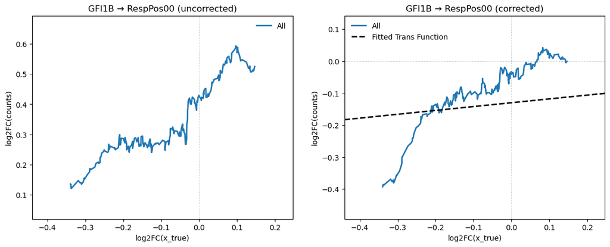

```python
gfi1b_df = trans_summaries["GFI1B"]
_known_responsive_dependent = (
    gfi1b_df.loc[
        gfi1b_df["feature"].isin(responsive_genes) & gfi1b_df["is_dependent"].fillna(False),
        ["feature", "fdr_alpha"],
    ]
    .sort_values("fdr_alpha")
)
example_feature = (
    _known_responsive_dependent["feature"].iloc[0]
    if len(_known_responsive_dependent) else responsive_genes[0]
)

plot_xy_data(
    trans_models["GFI1B"],
    feature=example_feature,
    modality_name="gene",
    show_correction="both",   # side-by-side uncorrected vs. alpha_y-corrected
    show_hill_function=True,
    log2fc=True,
    color_by=None,  # one line, one colour -- no split by technical group or NTC/targeting
)
```

## Proportion positive / negative / not-dependent

`single_hill` has no `classification` column (that's only computed for `additive_hill` — see `bayesDREAM/plotting/diagnostics.py`'s `plot_trans_hits_by_gene`, which explicitly requires it and won't work here). Building the equivalent 3-way split ourselves is direct: `n_a`'s sign gives the direction (positive Hill coefficient = increases with cis gene expression; negative = decreases), gated by `is_dependent`.

**Take the "dependent" fraction below with a grain of salt**: only 30 of the ~310 trans genes here have real simulated signal (~10%), but at this vignette's reduced `NITERS_TRANS` (a small fraction of `fit_trans()`'s own `niters=100,000` default) the posterior hasn't converged nearly as tightly as a real run would, and `is_dependent`'s FDR gate is more permissive on wide, noisy posteriors — so the observed "dependent" proportion below is inflated by false positives relative to what a fully-converged fit would call. Re-run with a much larger `NITERS_TRANS` (or the real `niters=100,000` via the Dardel array job above) before trusting these proportions on real data.

**The false positives also skew heavily "negative"** rather than splitting evenly between the two directions (visible in the bar chart below: ~30-50% "negative" vs only ~5% "positive" per cis gene). Checking against the known ground truth confirms this isn't a detection-power problem — true `RespPos`/`RespNeg` genes are recovered at comparable rates in both directions (13/15 and 15/15 in one run) — the imbalance comes almost entirely from background (null) genes being spuriously called "negative" far more often than "positive".

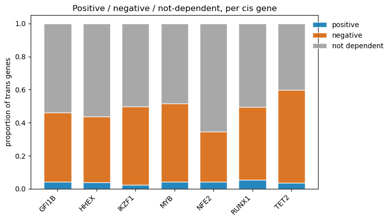

```python
DIRECTION_COLORS = {"positive": "#0072B2", "negative": "#D55E00", "not dependent": "#999999"}
DIRECTION_ORDER = ["positive", "negative", "not dependent"]


def classify_direction(df: pd.DataFrame) -> pd.Series:
    is_dep = df["is_dependent"].fillna(False).astype(bool)
    direction = pd.Series("not dependent", index=df.index)
    direction[is_dep & (df["n_a_median"] > 0)] = "positive"
    direction[is_dep & (df["n_a_median"] < 0)] = "negative"
    return pd.Categorical(direction, categories=DIRECTION_ORDER, ordered=True)


all_trans = pd.concat(
    [df.assign(cis_gene=gene) for gene, df in trans_summaries.items()], ignore_index=True
)
all_trans["direction"] = classify_direction(all_trans)

# --- overall proportion per cis gene ---
counts = pd.crosstab(all_trans["cis_gene"], all_trans["direction"]).reindex(columns=DIRECTION_ORDER)
proportions = counts.div(counts.sum(axis=1), axis=0)

fig, ax = plt.subplots(figsize=(8, 4.5))
bottom = np.zeros(len(proportions))
x = np.arange(len(proportions))
for d in DIRECTION_ORDER:
    vals = proportions[d].values
    ax.bar(x, vals, bottom=bottom, width=0.7, color=DIRECTION_COLORS[d], alpha=0.85,
           label=d, edgecolor="white", linewidth=1)
    bottom += vals
ax.set_xticks(x)
ax.set_xticklabels(proportions.index, rotation=45, ha="right")
ax.set_ylabel("proportion of trans genes")
ax.set_title("Positive / negative / not-dependent, per cis gene")
ax.legend(frameon=False, loc="upper right", bbox_to_anchor=(1.25, 1.0))
fig.tight_layout()
plt.show()
```

### ... vs. `y_ntc` (NTC baseline expression)

Bin trans genes by their own NTC expression level and look at how the positive/negative/not-dependent split shifts — e.g. whether dependence is harder to detect for lowly-expressed genes (more Poisson noise relative to signal) shows up here as a lower "dependent" fraction in the lowest bin.

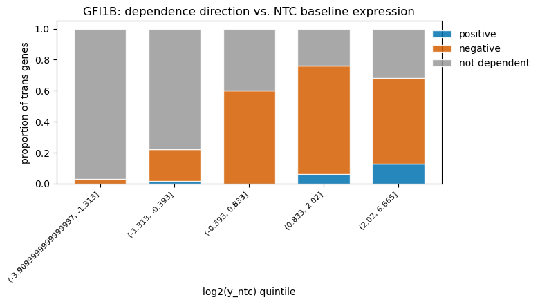

```python
fig, ax = plt.subplots(figsize=(8, 4.5))
gfi1b_df = trans_summaries["GFI1B"].assign(direction=classify_direction(trans_summaries["GFI1B"]))
gfi1b_df["log2_y_ntc_bin"] = pd.qcut(np.log2(gfi1b_df["y_ntc"].clip(lower=1e-3)), q=5, duplicates="drop")

counts_yntc = pd.crosstab(gfi1b_df["log2_y_ntc_bin"], gfi1b_df["direction"]).reindex(columns=DIRECTION_ORDER)
proportions_yntc = counts_yntc.div(counts_yntc.sum(axis=1), axis=0)

bottom = np.zeros(len(proportions_yntc))
x = np.arange(len(proportions_yntc))
for d in DIRECTION_ORDER:
    vals = proportions_yntc[d].values
    ax.bar(x, vals, bottom=bottom, width=0.7, color=DIRECTION_COLORS[d], alpha=0.85,
           label=d, edgecolor="white", linewidth=1)
    bottom += vals
ax.set_xticks(x)
ax.set_xticklabels([str(iv) for iv in proportions_yntc.index], rotation=45, ha="right", fontsize=8)
ax.set_xlabel("log2(y_ntc) quintile")
ax.set_ylabel("proportion of trans genes")
ax.set_title("GFI1B: dependence direction vs. NTC baseline expression")
ax.legend(frameon=False, loc="upper right", bbox_to_anchor=(1.25, 1.0))
fig.tight_layout()
plt.show()
```

### ... vs. `full_log2FC` (effect size)

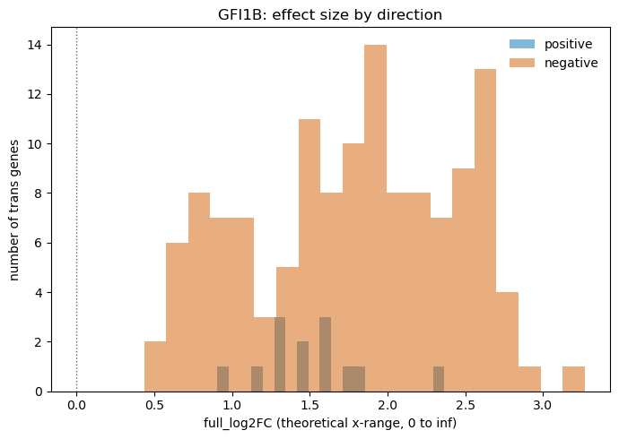

```python
fig, ax = plt.subplots(figsize=(7, 5))
for d in ["positive", "negative"]:
    vals = gfi1b_df.loc[gfi1b_df["direction"] == d, "full_log2fc_median"].dropna()
    if len(vals) < 2:
        continue
    ax.hist(vals, bins=20, color=DIRECTION_COLORS[d], alpha=0.5, label=d, edgecolor="none")
ax.axvline(0, color="#666666", lw=1, ls=":")
ax.set_xlabel("full_log2FC (theoretical x-range, 0 to inf)")
ax.set_ylabel("number of trans genes")
ax.set_title("GFI1B: effect size by direction")
ax.legend(frameon=False)
fig.tight_layout()
plt.show()
```

## EC50 (log2FC) vs. Hill coefficient `n`

`K_a_log2fc` (`= log2(K_a) - log2(x_ntc)`, i.e. the half-max point expressed as a cis-gene log2FC rather than a raw expression level) against `n_a_median` (cooperativity/steepness, sign = direction) — one panel per named gene, dependent trans genes only.

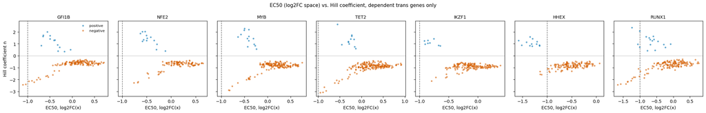

```python
fig, axes = plt.subplots(1, len(NAMED_GENES), figsize=(3.2 * len(NAMED_GENES), 3.6), sharey=True)
for ax, gene in zip(axes, NAMED_GENES):
    df = trans_summaries[gene]
    df = df.assign(direction=classify_direction(df))
    for d in ["positive", "negative"]:
        sub = df.loc[df["direction"] == d]
        ax.scatter(sub["K_a_log2fc"], sub["n_a_median"], s=14, alpha=0.6,
                   color=DIRECTION_COLORS[d], label=d, edgecolor="none")
    ax.axhline(0, color="#cccccc", lw=1, zorder=0)
    ax.axvline(-1.0, color="#666666", lw=1, ls="--", zorder=0)  # the same -1 threshold used earlier
    ax.set_title(gene, fontsize=10)
    ax.set_xlabel("EC50, log2FC(x)")
axes[0].set_ylabel("Hill coefficient n")
axes[0].legend(frameon=False, fontsize=8)
fig.suptitle("EC50 (log2FC space) vs. Hill coefficient, dependent trans genes only", fontsize=11)
fig.tight_layout()
plt.show()
```

## Proportion observed: `full_log2FC` vs. `observed_log2FC`

`full_log2fc` is the theoretical dynamic range (x from 0 to infinity); `observed_log2fc` is the same curve evaluated only over `[x_obs_min, x_obs_max]` — the x-range your guides actually achieved. Points well below the diagonal are genes where the fitted curve implies a much bigger range than your knock-down potency let you actually see (compare against the `fit_cis` vignette's "minimum x_eff_g log2FC per gene" plot — weak guides there predict exactly this pattern here).

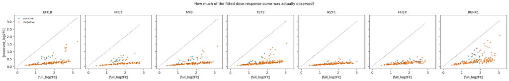

```python
fig, axes = plt.subplots(1, len(NAMED_GENES), figsize=(3.2 * len(NAMED_GENES), 3.6), sharex=True, sharey=True)
for ax, gene in zip(axes, NAMED_GENES):
    df = trans_summaries[gene]
    df = df.assign(direction=classify_direction(df))
    dep = df.loc[df["direction"] != "not dependent"]
    lim = float(np.nanmax([dep["full_log2fc_median"].abs().max(), dep["observed_log2fc"].abs().max(), 1.0])) \
        if len(dep) else 1.0
    ax.plot([0, lim], [0, lim], color="#999999", lw=1, ls="--", zorder=0)
    for d in ["positive", "negative"]:
        sub = dep.loc[dep["direction"] == d]
        ax.scatter(sub["full_log2fc_median"].abs(), sub["observed_log2fc"].abs(), s=14, alpha=0.6,
                   color=DIRECTION_COLORS[d], label=d, edgecolor="none")
    ax.set_title(gene, fontsize=10)
    ax.set_xlabel("|full_log2FC|")
axes[0].set_ylabel("|observed_log2FC|")
axes[0].legend(frameon=False, fontsize=8)
fig.suptitle("How much of the fitted dose-response curve was actually observed?", fontsize=11)
fig.tight_layout()
plt.show()
```